# Caracterización de tumores sólidos pediátricos según la infiltración del sistema inmune mediante datos transcriptómicos.

Trabajo Fin de Máster (TFM) Máster Universitario en Bioinformática y Bioestadística Área: Análisis de Datos Ómicos

María Ramírez García

2026-06-03

```r
# Impacto en sostenibilidad
inicio <- proc.time()
```

# Descripción

Este documento contiene el análisis transcriptómico realizado para la caracterización de tumores sólidos pediátricos según la infiltración del sistema inmune. El objetivo principal es explorar perfiles de expresión génica y estimar la presencia de distintos tipos celulares inmunes en muestras tumorales mediante herramientas bioinformáticas y análisis estadísticos en R.

# Descarga y preprocesado

## Carga de paquetes y librerias

## Funciones

### Normalización TPM

```r
normalizar_tpm <- function(rna_seq) {
  assay(rna_seq, "RPKM") <- assay(rna_seq)  #RPKM
  assay(rna_seq, "TPM") <- apply(assay(rna_seq, "RPKM"),2,function(x) x / sum(x) * 1e6)  # Calcular TPM
  return(rna_seq)
}
```

### Filtrado

Se eliminar los genes con baja expresión. (descarta expresión mediana inferior a 1 TPM)

```r
#descarta expresión mediana inferior a 1 TPM
filtrar_genes <- function(rna_seq) {
  drop <- which(apply(assay(rna_seq, "TPM"), 1, median) < 1)
  rna_seq <- rna_seq[-drop, ]
  rna_seq
}
```

### Graficos exploratotios de variables

Con el objetivo de evitar código redundante y mantener una representación homogénea entre cohortes, se definieron varias funciones para la generación automática de gráficos descriptivos de las variables clínicas seleccionadas.

```r
# Grafica sexo
plot_sex <- function(dataset, nombreCohorte, figura){

  p <- ggplot(dataset, aes(x = "", fill = SEX)) +
    geom_bar(width = 1) +
    coord_polar("y") +
    theme_void() +
    labs(
      title = paste(
        "Sexo en la cohorte de",
        nombreCohorte
      ),
      fill = "Sexo"
    ) +
    geom_text(
      stat = "count",
      size = 4,
      aes(label = paste0(
        after_stat(count),
        " (",
        round(after_stat(count / sum(count) * 100), 1),
        "%)"
      )),
      position = position_stack(vjust = 0.5)
    ) +
    theme(
      plot.title = element_text(
        size = 16,
        face = "bold",
        hjust = 0.5
      ),
      legend.title = element_text(
        size = 13,
        face = "bold"
      ),
      legend.text = element_text(
        size = 12
      )
    )

  print(p)

  ggsave(figura, plot = p, width = 7, height = 7, dpi = 300)
}


# Grafica edad
plot_age <- function(dataset, nombreCohorte, figura){

  p <- ggplot(dataset, aes(x = AGE)) +
    geom_histogram(
      binwidth = 1,
      fill = "steelblue",
      color = "black",
      boundary = 0
    ) +
    theme_classic() +
    labs(
      title = paste(
        "Edad en la cohorte de",
        nombreCohorte
      ),
      x = "Edad (años)",
      y = "Número de pacientes"
    ) +
    scale_x_continuous(
      breaks = seq(
        0,
        max(dataset$AGE, na.rm = TRUE),
        by = 1
      )
    ) +
    theme(
      plot.title = element_text(
        size = 16,
        face = "bold",
        hjust = 0.5
      ),
      axis.title = element_text(
        size = 13,
        face = "bold"
      ),
      axis.text = element_text(
        size = 11
      )
    )

  print(p)

  ggsave(figura, plot = p, width = 7, height = 7, dpi = 300)
}


# Grafica estadio clínico
plot_stage <- function(dataset, nombreCohorte, figura){

  p <- ggplot(dataset, aes(x = CLINICAL_STAGE)) +
    geom_bar(
      fill = "darkcyan",
      color = "black"
    ) +
    theme_classic() +
    labs(
      title = paste(
        "Estadios clínicos en la cohorte de",
        nombreCohorte
      ),
      x = "Estadio",
      y = "Número de pacientes"
    ) +
    theme(
      plot.title = element_text(
        size = 16,
        face = "bold",
        hjust = 0.5
      ),
      axis.title = element_text(
        size = 13,
        face = "bold"
      ),
      axis.text = element_text(
        size = 11
      )
    )

  print(p)

  ggsave(figura, plot = p, width = 7, height = 7, dpi = 300)
}


# Grafica estado vital
plot_os <- function(dataset, nombreCohorte, figura){

  p <- ggplot(dataset, aes(x = "", fill = OS_STATUS)) +
    geom_bar(width = 1) +
    coord_polar("y") +
    theme_void() +
    labs(
      title = paste(
        "Supervivencia en la cohorte de",
        nombreCohorte
      ),
      fill = "Estado vital"
    ) +
    scale_fill_brewer(
      palette = "Dark2",
      na.value = "gray60"
    ) +
    geom_text(
      stat = "count",
      size = 4,
      aes(label = paste0(
        after_stat(count),
        " (",
        round(after_stat(count / sum(count) * 100), 1),
        "%)"
      )),
      position = position_stack(vjust = 0.5)
    ) +
    theme(
      plot.title = element_text(
        size = 16,
        face = "bold",
        hjust = 0.5
      ),
      legend.title = element_text(
        size = 13,
        face = "bold"
      ),
      legend.text = element_text(
        size = 12
      )
    )

  print(p)

  ggsave(figura, plot = p, width = 7, height = 7, dpi = 300)
}
```

### Análisis clínico: sexo y edad.

```r
# Función de análisis
analisis_limma <- function(m_scores, cohorte, resultado) {

    design <- model.matrix(~ cohorte$SEX + cohorte$AGE)
    fit <- lmFit(m_scores, design)
    fit_ebayes <- eBayes(fit)

    # Resultados sexo
    res_sex <- topTable(
        fit_ebayes,
        coef = "cohorte$SEXMale",
        number = Inf,
        adjust.method = "BH"
    )

    # Resultados edad
    res_age <- topTable(
        fit_ebayes,
        coef = "cohorte$AGE",
        number = Inf,
        adjust.method = "BH"
    )

    # Guardar resultados en R
    resultado$res_sex <- res_sex
    resultado$res_age <- res_age
    resultado$fit <- fit_ebayes

    return(resultado)
}


# Función boxplot sexo
plot_boxplot_sex <- function(m_scores, cohorte, resultado) {

    p <- ggplot(
        pivot_longer(
            data.frame(
                t(m_scores),
                SEX = cohorte$SEX
            ),
            cols = -SEX,
            names_to = "celltype",
            values_to = "score"
        ),
        aes(SEX, score, fill = SEX)
    ) +
        geom_boxplot() +
        geom_jitter(width = 0.1, size = 0.8) +
        facet_wrap(~ celltype, scales = "free_y") +
        theme_bw()

    # Guardar gráfica fuera de R
    ggsave(
        filename = paste0(resultado, "_boxplot_sex.png"),
        plot = p,
        width = 12,
        height = 8
    )

    return(p)
}


# Función gráfico de dispersión edad
plot_scatter_age <- function(m_scores, cohorte, resultado) {

    p <- ggplot(
        pivot_longer(
            data.frame(
                t(m_scores),
                AGE = cohorte$AGE
            ),
            cols = -AGE,
            names_to = "celltype",
            values_to = "score"
        ),
        aes(AGE, score)
    ) +
        geom_point(size = 1) +
        geom_smooth(method = "lm") +
        facet_wrap(~ celltype, scales = "free_y") +
        theme_bw()

    # Guardar gráfica fuera de R
    ggsave(
        filename = paste0(resultado, "_scatter_age.png"),
        plot = p,
        width = 12,
        height = 8
    )

    return(p)
}
```

### Análisis clínico: Supervivencia

```r
# Preparar datos para análisis de supervivencia KM
preparar_cohorte <- function(cohorte, scores_mat) {
  clinc <- data.frame( sample_id = cohorte$PATIENT_ID, OS_STATUS = cohorte$OS_STATUS, OS_MONTHS = cohorte$OS_MONTHS ) %>%
  mutate(OS_STATUS = as.integer(substr(OS_STATUS, 1, 1))) %>%
  filter(!is.na(OS_STATUS), !is.na(OS_MONTHS))
  results_t <- as.data.frame(t(scores_mat)) %>% rownames_to_column("sample_id")
  inner_join(clinc, results_t, by = "sample_id")
}

# Categorizar los scores de las cohortes en "High" y "Low"
categorizar <- function(data_cohorte) {
  for (cel in tip_cel) {
    med <- median(data_cohorte[[cel]], na.rm = TRUE)
    data_cohorte[[paste0(cel, "_group")]] <- factor(
      ifelse(data_cohorte[[cel]] >= med, "High", "Low"),
      levels = c("Low", "High")
    )
  }
  data_cohorte
}
```

## Visualización estudios de cBioPortal

```r
cbio <- cBioPortal() #
studies <- getStudies(cbio, buildReport = TRUE)

# Busqueda de estudios pediatricos.
studies[grep("pediatric", studies$name, ignore.case = TRUE), ]
```

```
## # A tibble: 18 × 15
##    name          description publicStudy pmid  citation groups status importDate
##    <chr>         <chr>       <lgl>       <chr> <chr>    <chr>   <int> <chr>
##  1 Pediatric Br… "Integrate… TRUE        3324… CPTAC, … "PUBL…      0 2026-01-0…
##  2 Pediatric Eu… "Whole-exo… TRUE        3529… Berlang… ""          0 2026-01-1…
##  3 Pediatric so… "Whole gen… TRUE        3799… Funan e… "PUBL…      0 2026-01-1…
##  4 Pediatric Rh… "Whole-gen… TRUE        <NA>  <NA>     "NCI-…      0 2026-02-1…
##  5 Pediatric Ac… "Whole gen… TRUE        <NA>  <NA>     "NCI-…      0 2026-01-0…
##  6 Pediatric Lo… "Whole gen… TRUE        3358… Fisher,… "PUBL…      0 2026-03-0…
##  7 Pediatric Ne… "Whole gen… TRUE        <NA>  <NA>     "NCI-…      0 2026-01-0…
##  8 Pediatric Ew… "Whole exo… TRUE        2518… Crompto… "PUBL…      0 2026-01-0…
##  9 Pediatric Rh… "Targeted … TRUE        3731… de Ward… ""          0 2026-01-1…
## 10 Pediatric Ne… "Targeted … TRUE        3716… Gunes e… ""          0 2026-02-1…
## 11 Pediatric Pa… "Targeted … TRUE        3558… Shukla,… ""          0 2026-04-0…
## 12 Pediatric Wi… "Whole-exo… TRUE        <NA>  <NA>     "NCI-…      0 2026-01-1…
## 13 Pediatric Pa… "Whole exo… TRUE        2800… Oberg e… "PUBL…      0 2026-01-0…
## 14 Pediatric Ac… "Molecular… TRUE        3821… Umeda, … ""          0 2026-03-1…
## 15 Pediatric Ac… "Whole gen… TRUE        <NA>  <NA>     "NCI-…      0 2026-01-0…
## 16 Pediatric Tu… "Targeted … TRUE        <NA>  <NA>     ""          0 2026-02-1…
## 17 Pediatric Pr… "Whole-exo… TRUE        3169… Rotika … "PUBL…      0 2026-01-1…
## 18 Pediatric Pa… "Whole-gen… TRUE        2948… Grobner… "PUBL…      0 2026-01-1…
## # ℹ 7 more variables: allSampleCount <int>, readPermission <lgl>,
## #   studyId <chr>, cancerTypeId <chr>, referenceGenome <chr>, api_build <lgl>,
## #   pack_build <lgl>
```

Tras una búsqueda con R y el portal web de cBioPortal, se seleccionaron 4 cohortes diferentes para el análisis.

- *Pediatric Rhabdoid Tumor (TARGET, 2018)*
- *Pediatric Wilms’ Tumor (TARGET, 2018)*
- *Pediatric Neuroblastoma (TARGET, 2018)*
- *Pediatric Brain Cancer (CPTAC/CHOP, Cell 2020)*

```r
# Estudios seleccionados
estudios <- c(rt ="rt_target_2018_pub", brain = "brain_cptac_2020", wt = "wt_target_2018_pub", nbl= "nbl_target_2018_pub")
```

### **Pediatric Rhabdoid Tumor (TARGET, 2018)**

```r
# Comprobar y ver archivos de RNA-Seq
# Averiguar donde se encuentran los datos adecuados para el análisis
molecularProfiles(cbio,estudios["rt"])
```

```
## # A tibble: 6 × 8
##   molecularAlterationType datatype   name     description showProfileInAnalysi…¹
##   <chr>                   <chr>      <chr>    <chr>       <lgl>
## 1 MRNA_EXPRESSION         CONTINUOUS microRN… Expression… FALSE
## 2 MRNA_EXPRESSION         Z-SCORE    microRN… microRNA e… TRUE
## 3 MUTATION_EXTENDED       MAF        Somatic… Somatic mu… TRUE
## 4 MRNA_EXPRESSION         CONTINUOUS mRNA ex… Expression… FALSE
## 5 MRNA_EXPRESSION         Z-SCORE    mRNA ex… mRNA z-Sco… TRUE
## 6 MRNA_EXPRESSION         Z-SCORE    mRNA ex… Log-transf… TRUE
## # ℹ abbreviated name: ¹showProfileInAnalysisTab
## # ℹ 3 more variables: patientLevel <lgl>, molecularProfileId <chr>,
## #   studyId <chr>
```

Se confirma que contiene un archivo de expresión mRNA (RNA Seq RPKM)

```r
# Trabajar con la cohorte
rt <- cBioDataPack(estudios["rt"], ask = FALSE)
```

```
## Working on: C:\Users\maria\AppData\Local\Temp\RtmpCU2DsM/rt_target_2018_pub/rt_target_2018_pub/data_gene_panel_matrix.txt
```

```
## Working on: C:\Users\maria\AppData\Local\Temp\RtmpCU2DsM/rt_target_2018_pub/rt_target_2018_pub/data_mirna.txt
```

```
## Working on: C:\Users\maria\AppData\Local\Temp\RtmpCU2DsM/rt_target_2018_pub/rt_target_2018_pub/data_mirna_zscores.txt
```

```
## Working on: C:\Users\maria\AppData\Local\Temp\RtmpCU2DsM/rt_target_2018_pub/rt_target_2018_pub/data_mrna_seq_rpkm.txt
```

```
## Working on: C:\Users\maria\AppData\Local\Temp\RtmpCU2DsM/rt_target_2018_pub/rt_target_2018_pub/data_mrna_seq_rpkm_zscores_ref_all_samples.txt
```

```
## Working on: C:\Users\maria\AppData\Local\Temp\RtmpCU2DsM/rt_target_2018_pub/rt_target_2018_pub/data_mrna_seq_rpkm_zscores_ref_diploid_samples.txt
```

```
## Working on: C:\Users\maria\AppData\Local\Temp\RtmpCU2DsM/rt_target_2018_pub/rt_target_2018_pub/data_mutations.txt
```

```
## harmonizing input:
##   removing 29 colData rownames not in sampleMap 'primary'
```

```r
rt # MultiAssayExperiment
```

```
## A MultiAssayExperiment object of 6 listed
##  experiments with user-defined names and respective classes.
##  Containing an ExperimentList class object of length 6:
##  [1] mirna: SummarizedExperiment with 1594 rows and 43 columns
##  [2] mirna_zscores: SummarizedExperiment with 1594 rows and 43 columns
##  [3] mrna_seq_rpkm: SummarizedExperiment with 26136 rows and 43 columns
##  [4] mrna_seq_rpkm_zscores_ref_all_samples: SummarizedExperiment with 26136 rows and 43 columns
##  [5] mrna_seq_rpkm_zscores_ref_diploid_samples: SummarizedExperiment with 26136 rows and 43 columns
##  [6] mutations: RaggedExperiment with 122 rows and 34 columns
## Functionality:
##  experiments() - obtain the ExperimentList instance
##  colData() - the primary/phenotype DataFrame
##  sampleMap() - the sample coordination DataFrame
##  `$`, `[`, `[[` - extract colData columns, subset, or experiment
##  *Format() - convert into a long or wide DataFrame
##  assays() - convert ExperimentList to a SimpleList of matrices
##  exportClass() - save data to flat files
```

A continuación se crea un SummarizedExperiment con los datos correspondientes al RNA-Seq

```r
# Extraer datos de RNA-Seq y los datos clínicos asociados
rt_rna_seq <- getWithColData(rt, "mrna_seq_rpkm")# SummarizedExperiment con datos iniciales
```

Exploración de los datos

```r
# Visualización del SE
rt_rna_seq
```

```
## class: SummarizedExperiment
## dim: 26136 43
## metadata(0):
## assays(1): ''
## rownames(26136): 7105 64102 ... 55957 102725415
## rowData names(2): Hugo_Symbol Entrez_Gene_Id
## colnames(43): TARGET-52-NAAELV TARGET-52-NAAELY ... TARGET-52-PAUHAZ
##   TARGET-52-PAUNPA
## colData names(24): PATIENT_ID SAMPLE_ID ... HISTOLOGICAL_TYPE
##   PATIENT_DEATH_REASON
```

```r
# Cambiar las filas por Hugo_Symbol
rownames(rt_rna_seq) <- rowData(rt_rna_seq)$Hugo_Symbol
# Comprobar si hay valores NA en el assay
sum(is.na(assay(rt_rna_seq)))
```

```
## [1] 0
```

```r
# Valores duplicados
table(table(rt_rna_seq$PATIENT_ID))
```

```
##
##  1
## 43
```

En el SE no se encuentran valores NA ni duplicaciones en las muestras, sin embargo la identificación de los genes es Entrez_Gene_Id por lo que se cambia a Hugo_symbol.

```r
# Normalizar y filtrar los datos de RNA-Seq
rt_rna_seq <- normalizar_tpm(rt_rna_seq) # Datos iniciales y normalizados (TPM)
rt_rna_seq_fil <-filtrar_genes(rt_rna_seq) # Filtrado
# comprobamos con las dimensiones
dim(rt_rna_seq)
```

```
## [1] 26136    43
```

```r
dim(rt_rna_seq_fil)
```

```
## [1] 13142    43
```

Tras filtrar las filas han disminuido, lo que indica que una gran cantidad de genes presenta una una expresión inferior a 1TMP

### **Pediatric Wilms’ Tumor (TARGET, 2018)**

```r
# WT
# Comprobar y ver archivos de RNA-Seq
molecularProfiles(cbio,estudios["wt"]) #el RNA-Seq esta (RPKM))
```

```
## # A tibble: 10 × 8
##    molecularAlterationType datatype   name    description showProfileInAnalysi…¹
##    <chr>                   <chr>      <chr>   <chr>       <lgl>
##  1 COPY_NUMBER_ALTERATION  DISCRETE   Putati… Putative c… TRUE
##  2 METHYLATION             CONTINUOUS Methyl… Methylatio… FALSE
##  3 MRNA_EXPRESSION         CONTINUOUS microR… Expression… FALSE
##  4 MRNA_EXPRESSION         CONTINUOUS mRNA e… mRNA expre… FALSE
##  5 MRNA_EXPRESSION         Z-SCORE    mRNA e… mRNA z-Sco… TRUE
##  6 MRNA_EXPRESSION         Z-SCORE    mRNA e… Log-transf… TRUE
##  7 MUTATION_EXTENDED       MAF        Somati… Somatic mu… TRUE
##  8 MRNA_EXPRESSION         CONTINUOUS mRNA e… Expression… FALSE
##  9 MRNA_EXPRESSION         Z-SCORE    mRNA e… mRNA z-Sco… TRUE
## 10 MRNA_EXPRESSION         Z-SCORE    mRNA e… Log-transf… TRUE
## # ℹ abbreviated name: ¹showProfileInAnalysisTab
## # ℹ 3 more variables: patientLevel <lgl>, molecularProfileId <chr>,
## #   studyId <chr>
```

```r
# Trabajar con el cohorte
wt <- cBioDataPack(estudios["wt"], ask = FALSE)
```

```
## Working on: C:\Users\maria\AppData\Local\Temp\RtmpCU2DsM/wt_target_2018_pub/wt_target_2018_pub/data_cna.txt
```

```
## Working on: C:\Users\maria\AppData\Local\Temp\RtmpCU2DsM/wt_target_2018_pub/wt_target_2018_pub/data_cna_hg19.seg
```

```
## Working on: C:\Users\maria\AppData\Local\Temp\RtmpCU2DsM/wt_target_2018_pub/wt_target_2018_pub/data_methylation_hm450.txt
```

```
## Working on: C:\Users\maria\AppData\Local\Temp\RtmpCU2DsM/wt_target_2018_pub/wt_target_2018_pub/data_mirna.txt
```

```
## Working on: C:\Users\maria\AppData\Local\Temp\RtmpCU2DsM/wt_target_2018_pub/wt_target_2018_pub/data_mrna_agilent_microarray.txt
```

```
## Working on: C:\Users\maria\AppData\Local\Temp\RtmpCU2DsM/wt_target_2018_pub/wt_target_2018_pub/data_mrna_agilent_microarray_zscores_ref_all_samples.txt
```

```
## Working on: C:\Users\maria\AppData\Local\Temp\RtmpCU2DsM/wt_target_2018_pub/wt_target_2018_pub/data_mrna_agilent_microarray_zscores_ref_diploid_samples.txt
```

```
## Working on: C:\Users\maria\AppData\Local\Temp\RtmpCU2DsM/wt_target_2018_pub/wt_target_2018_pub/data_mrna_seq_rpkm.txt
```

```
## Working on: C:\Users\maria\AppData\Local\Temp\RtmpCU2DsM/wt_target_2018_pub/wt_target_2018_pub/data_mrna_seq_rpkm_zscores_ref_all_samples.txt
```

```
## Working on: C:\Users\maria\AppData\Local\Temp\RtmpCU2DsM/wt_target_2018_pub/wt_target_2018_pub/data_mrna_seq_rpkm_zscores_ref_diploid_samples.txt
```

```
## Working on: C:\Users\maria\AppData\Local\Temp\RtmpCU2DsM/wt_target_2018_pub/wt_target_2018_pub/data_mutations.txt
```

```
## harmonizing input:
##   removing 524 colData rownames not in sampleMap 'primary'
```

```r
wt # MultiAssayExperiment
```

```
## A MultiAssayExperiment object of 11 listed
##  experiments with user-defined names and respective classes.
##  Containing an ExperimentList class object of length 11:
##  [1] cna: SummarizedExperiment with 20641 rows and 129 columns
##  [2] cna_hg19.seg: RaggedExperiment with 60454 rows and 129 columns
##  [3] methylation_hm450: SummarizedExperiment with 15045 rows and 126 columns
##  [4] mirna: SummarizedExperiment with 1870 rows and 132 columns
##  [5] mrna_agilent_microarray: SummarizedExperiment with 20486 rows and 127 columns
##  [6] mrna_agilent_microarray_zscores_ref_all_samples: SummarizedExperiment with 20486 rows and 127 columns
##  [7] mrna_agilent_microarray_zscores_ref_diploid_samples: SummarizedExperiment with 16349 rows and 127 columns
##  [8] mrna_seq_rpkm: SummarizedExperiment with 23968 rows and 130 columns
##  [9] mrna_seq_rpkm_zscores_ref_all_samples: SummarizedExperiment with 23968 rows and 130 columns
##  [10] mrna_seq_rpkm_zscores_ref_diploid_samples: SummarizedExperiment with 23926 rows and 130 columns
##  [11] mutations: RaggedExperiment with 882 rows and 102 columns
## Functionality:
##  experiments() - obtain the ExperimentList instance
##  colData() - the primary/phenotype DataFrame
##  sampleMap() - the sample coordination DataFrame
##  `$`, `[`, `[[` - extract colData columns, subset, or experiment
##  *Format() - convert into a long or wide DataFrame
##  assays() - convert ExperimentList to a SimpleList of matrices
##  exportClass() - save data to flat files
```

```r
# Extraer datos de RNA-Seq y los datos clínicos asociados
wt_rna_seq <- getWithColData(wt, "mrna_seq_rpkm")# SummarizedExperiment con datos iniciales
```

```
## Warning: 'experiments' dropped; see 'drops()'
```

```
## Warning: Duplicating colData rows due to replicates in 'replicated(x)'
```

Al extraer los datos, se muestra un aviso que indica que el se tiene duplicaciones.

```r
# Visualización del SE
wt_rna_seq
```

```
## class: SummarizedExperiment
## dim: 23968 130
## metadata(0):
## assays(1): ''
## rownames(23968): TSPAN6 TNMD ... SMIM22 LIN37
## rowData names(2): Hugo_Symbol Entrez_Gene_Id
## colnames(130): TARGET-50-CAAAAB TARGET-50-CAAAAC ... TARGET-50-PALKRS
##   TARGET-50-PALLFB
## colData names(24): PATIENT_ID SAMPLE_ID ... OS_DAYS
##   PATIENT_DEATH_REASON
```

```r
# Comprobar si hay valores NA en el assay
sum(is.na(assay(wt_rna_seq)))
```

```
## [1] 0
```

```r
# Valores duplicados
table(table(wt_rna_seq$PATIENT_ID))
```

```
##
##   1   2
## 120   5
```

En esta ocasión no hay valores NA pero si 5 muestras duplicadas. nos quedaremos con la inicial.

```r
#Eliminar duplicados
wt_rna_seq <- wt_rna_seq[, !duplicated(wt_rna_seq$PATIENT_ID)]
table(table(wt_rna_seq$PATIENT_ID)) # comprobar que se han eliminado
```

```
##
##   1
## 125
```

Ya están limpios ahora se preprocesan

```r
# Normalizar y filtrar los datos de RNA-Seq
wt_rna_seq <- normalizar_tpm(wt_rna_seq) # Datos iniciales y normalizados (TPM)
wt_rna_seq_fil <-filtrar_genes(wt_rna_seq) # Filtrado
# comprobamos con las dimensiones
dim(wt_rna_seq)
```

```
## [1] 23968   125
```

```r
dim(wt_rna_seq_fil)
```

```
## [1] 14313   125
```

### **Pediatric Neuroblastoma (TARGET, 2018)**

```r
# nbl
# Comprobar y ver archivos de RNA-Seq
molecularProfiles(cbio,estudios["nbl"]) #(RPKM)
```

```
## # A tibble: 8 × 8
##   molecularAlterationType datatype   name     description showProfileInAnalysi…¹
##   <chr>                   <chr>      <chr>    <chr>       <lgl>
## 1 COPY_NUMBER_ALTERATION  DISCRETE   Putativ… Putative c… TRUE
## 2 MRNA_EXPRESSION         CONTINUOUS mRNA ex… mRNA expre… FALSE
## 3 MRNA_EXPRESSION         Z-SCORE    mRNA ex… mRNA z-Sco… TRUE
## 4 MRNA_EXPRESSION         Z-SCORE    mRNA ex… Log-transf… TRUE
## 5 MUTATION_EXTENDED       MAF        Somatic… Somatic mu… TRUE
## 6 MRNA_EXPRESSION         CONTINUOUS mRNA ex… Expression… FALSE
## 7 MRNA_EXPRESSION         Z-SCORE    mRNA ex… mRNA z-Sco… TRUE
## 8 MRNA_EXPRESSION         Z-SCORE    mRNA ex… Log-transf… TRUE
## # ℹ abbreviated name: ¹showProfileInAnalysisTab
## # ℹ 3 more variables: patientLevel <lgl>, molecularProfileId <chr>,
## #   studyId <chr>
```

```r
# Trabajar con el cohorte
nbl <- cBioDataPack(estudios["nbl"], ask = FALSE)
```

```
## Working on: C:\Users\maria\AppData\Local\Temp\RtmpCU2DsM/nbl_target_2018_pub/nbl_target_2018_pub/data_cna.txt
```

```
## Working on: C:\Users\maria\AppData\Local\Temp\RtmpCU2DsM/nbl_target_2018_pub/nbl_target_2018_pub/data_cna_hg19.seg
```

```
## Working on: C:\Users\maria\AppData\Local\Temp\RtmpCU2DsM/nbl_target_2018_pub/nbl_target_2018_pub/data_mrna_agilent_microarray.txt
```

```
## Working on: C:\Users\maria\AppData\Local\Temp\RtmpCU2DsM/nbl_target_2018_pub/nbl_target_2018_pub/data_mrna_agilent_microarray_zscores_ref_all_samples.txt
```

```
## Working on: C:\Users\maria\AppData\Local\Temp\RtmpCU2DsM/nbl_target_2018_pub/nbl_target_2018_pub/data_mrna_agilent_microarray_zscores_ref_diploid_samples.txt
```

```
## Working on: C:\Users\maria\AppData\Local\Temp\RtmpCU2DsM/nbl_target_2018_pub/nbl_target_2018_pub/data_mrna_seq_rpkm.txt
```

```
## Working on: C:\Users\maria\AppData\Local\Temp\RtmpCU2DsM/nbl_target_2018_pub/nbl_target_2018_pub/data_mrna_seq_rpkm_zscores_ref_all_samples.txt
```

```
## Working on: C:\Users\maria\AppData\Local\Temp\RtmpCU2DsM/nbl_target_2018_pub/nbl_target_2018_pub/data_mrna_seq_rpkm_zscores_ref_diploid_samples.txt
```

```
## Working on: C:\Users\maria\AppData\Local\Temp\RtmpCU2DsM/nbl_target_2018_pub/nbl_target_2018_pub/data_mutations.txt
```

```
## harmonizing input:
##   removing 350 colData rownames not in sampleMap 'primary'
```

```r
nbl # MultiAssayExperiment
```

```
## A MultiAssayExperiment object of 9 listed
##  experiments with user-defined names and respective classes.
##  Containing an ExperimentList class object of length 9:
##  [1] cna: SummarizedExperiment with 20641 rows and 59 columns
##  [2] cna_hg19.seg: RaggedExperiment with 13424 rows and 59 columns
##  [3] mrna_agilent_microarray: SummarizedExperiment with 23434 rows and 249 columns
##  [4] mrna_agilent_microarray_zscores_ref_all_samples: SummarizedExperiment with 23434 rows and 249 columns
##  [5] mrna_agilent_microarray_zscores_ref_diploid_samples: SummarizedExperiment with 20787 rows and 249 columns
##  [6] mrna_seq_rpkm: SummarizedExperiment with 23015 rows and 143 columns
##  [7] mrna_seq_rpkm_zscores_ref_all_samples: SummarizedExperiment with 23434 rows and 249 columns
##  [8] mrna_seq_rpkm_zscores_ref_diploid_samples: SummarizedExperiment with 23015 rows and 143 columns
##  [9] mutations: RaggedExperiment with 1035 rows and 372 columns
## Functionality:
##  experiments() - obtain the ExperimentList instance
##  colData() - the primary/phenotype DataFrame
##  sampleMap() - the sample coordination DataFrame
##  `$`, `[`, `[[` - extract colData columns, subset, or experiment
##  *Format() - convert into a long or wide DataFrame
##  assays() - convert ExperimentList to a SimpleList of matrices
##  exportClass() - save data to flat files
```

```r
# Extraer datos de RNA-Seq y los datos clinicos asociados
nbl_rna_seq <- getWithColData(nbl, "mrna_seq_rpkm")# SummarizedExperiment con datos iniciales
```

```
## Warning: 'experiments' dropped; see 'drops()'
```

```
## Warning: Duplicating colData rows due to replicates in 'replicated(x)'
```

Al extraer los datos, se muestra un aviso que indica que el SE tiene duplicaciones.

```r
# Visualización del SE
nbl_rna_seq
```

```
## class: SummarizedExperiment
## dim: 23015 143
## metadata(0):
## assays(1): ''
## rownames(23015): TSPAN6 TNMD ... LOXL1-AS1 LINC00662
## rowData names(2): Hugo_Symbol Entrez_Gene_Id
## colnames(143): TARGET-30-PAIFXV TARGET-30-PAIPGU ... TARGET-30-PATINJ
##   TARGET-30-PATNKP
## colData names(44): PATIENT_ID SAMPLE_ID ... RELAPSE_PERCENT_NECROSIS
##   RELAPSE_PERCENT_STROMA
```

```r
# Comprobar si hay valores NA en el assay
sum(is.na(assay(nbl_rna_seq)))
```

```
## [1] 42424
```

Al comprobar los valores NA se muestra que hay una gran cantidad de estos, a continuación observamos como se distribuyen

```r
#Eliminar NA
# cuantas columnas tienen NA
sum(colSums(is.na(assay(nbl_rna_seq))) > 0)
```

```
## [1] 43
```

```r
# Como se destribuyen. Cuantas no tienen y cuantas si
table(colSums(is.na(assay(nbl_rna_seq))))
```

```
##
##     0     1     2     3     4     5     6    11    25 19758 22525
##   100    13     9     2     9     4     2     1     1     1     1
```

Los valores NA se centran en 43 columnas, lo que indica que de las 143 muestras, 43 contienen NA. Posteriormente se observa como están distribuidos dentro de cada muestra. Tras una observación mas detallada se puede ver que hay 100 muestras (columnas) sin ningún valor NA, 2 muestras con la mayor parte de NA y 41 muestras que contienen entre 1 y 25 valores NA. Para evitar futuros errores se eliminan todas las muestras que contengan valores NA y se trabaja con las 100 muestras limpias.

```r
# Eliminar columnas con valores NA
colum_NA <- colSums(is.na(assay(nbl_rna_seq))) == 0
nbl_rna_seq<- nbl_rna_seq[, colum_NA]
# comprobación
sum(is.na(assay(nbl_rna_seq)))
```

```
## [1] 0
```

```r
dim(nbl_rna_seq) # Hay 100 muestras (columnas)
```

```
## [1] 23015   100
```

se han eliminado las 43 columnas que contenian NA. A continución se miran las duplicaciones

```r
# Valores duplicados
table(table(nbl_rna_seq$PATIENT_ID))
```

```
##
##  1  2
## 96  2
```

Tras eliminar valores NA vemos que las muestras duplicadas son 2. Se eliminan, manteniendo la primera muestra.

```r
# Eliminar muestras duplicadas
nbl_rna_seq <- nbl_rna_seq[, !duplicated(nbl_rna_seq$PATIENT_ID)]
table(table(nbl_rna_seq$PATIENT_ID))
```

```
##
##  1
## 98
```

Se han eliminado las muestras duplicadas y aquellas que podrían causar problemas por contener valores NA quedando 98 muestras en total. Después de limpiar se normalizan y filtran los datos.

```r
# Normalizar y filtrar
nbl_rna_seq <- normalizar_tpm(nbl_rna_seq) # Normalizar
nbl_rna_seq_fil <-filtrar_genes(nbl_rna_seq) # Filtrado

# comprobamos con las dimensiones
dim(nbl_rna_seq)
```

```
## [1] 23015    98
```

```r
dim(nbl_rna_seq_fil)
```

```
## [1] 14323    98
```

### **Pediatric Brain Cancer (CPTAC/CHOP, Cell 2020)**

```r
# Comprobar y ver archivos de RNA-Seq
molecularProfiles(cbio,estudios["brain"])
```

```
## # A tibble: 8 × 10
##   molecularAlterationType datatype    name    description showProfileInAnalysi…¹
##   <chr>                   <chr>       <chr>   <chr>       <lgl>
## 1 COPY_NUMBER_ALTERATION  DISCRETE    Discre… Predicted … TRUE
## 2 COPY_NUMBER_ALTERATION  LOG2-VALUE  Log2 o… Predicted … FALSE
## 3 MUTATION_EXTENDED       MAF         Mutati… Calls from… TRUE
## 4 GENERIC_ASSAY           LIMIT-VALUE Phosph… Phosphopro… FALSE
## 5 PROTEIN_LEVEL           LOG2-VALUE  Protei… Protein le… FALSE
## 6 PROTEIN_LEVEL           Z-SCORE     Z scor… Z scores o… TRUE
## 7 MRNA_EXPRESSION         CONTINUOUS  RNA ex… Log2 of FP… FALSE
## 8 MRNA_EXPRESSION         Z-SCORE     RNA ex… Expression… TRUE
## # ℹ abbreviated name: ¹showProfileInAnalysisTab
## # ℹ 5 more variables: patientLevel <lgl>, molecularProfileId <chr>,
## #   studyId <chr>, genericAssayType <chr>, pivotThreshold <dbl>
```

En esta cohorte el archivo de expresión mRNA contiene los count transformados (Log2 of FPKM + 1 expresstion values). Para parte del análisis se puede trabajar con ellos en este formato. Sin embargo, para tenerlo en el mismo formato que los demás cohortes, se calculara una aproximación a los valores iniciales FPKM.

```r
# Trabajar con el cohorte
brain <- cBioDataPack(estudios["brain"], ask = FALSE)
```

```
## Working on: C:\Users\maria\AppData\Local\Temp\RtmpCU2DsM/brain_cptac_2020/brain_cptac_2020/data_cna.txt
```

```
## Working on: C:\Users\maria\AppData\Local\Temp\RtmpCU2DsM/brain_cptac_2020/brain_cptac_2020/data_gene_panel_matrix.txt
```

```
## Working on: C:\Users\maria\AppData\Local\Temp\RtmpCU2DsM/brain_cptac_2020/brain_cptac_2020/data_linear_cna.txt
```

```
## Working on: C:\Users\maria\AppData\Local\Temp\RtmpCU2DsM/brain_cptac_2020/brain_cptac_2020/data_mrna_seq_v2_rsem.txt
```

```
## Working on: C:\Users\maria\AppData\Local\Temp\RtmpCU2DsM/brain_cptac_2020/brain_cptac_2020/data_mrna_seq_v2_rsem_zscores_ref_all_samples.txt
```

```
## Working on: C:\Users\maria\AppData\Local\Temp\RtmpCU2DsM/brain_cptac_2020/brain_cptac_2020/data_mutations.txt
```

```
## Working on: C:\Users\maria\AppData\Local\Temp\RtmpCU2DsM/brain_cptac_2020/brain_cptac_2020/data_phosphoprotein_quantification.txt
```

```
## Working on: C:\Users\maria\AppData\Local\Temp\RtmpCU2DsM/brain_cptac_2020/brain_cptac_2020/data_protein_quantification.txt
```

```
## Working on: C:\Users\maria\AppData\Local\Temp\RtmpCU2DsM/brain_cptac_2020/brain_cptac_2020/data_protein_quantification_zscores.txt
```

```r
brain # MultiAssayExperiment
```

```
## A MultiAssayExperiment object of 7 listed
##  experiments with user-defined names and respective classes.
##  Containing an ExperimentList class object of length 7:
##  [1] cna: SummarizedExperiment with 19380 rows and 190 columns
##  [2] linear_cna: SummarizedExperiment with 19380 rows and 190 columns
##  [3] mrna_seq_v2_rsem: SummarizedExperiment with 18209 rows and 188 columns
##  [4] mrna_seq_v2_rsem_zscores_ref_all_samples: SummarizedExperiment with 18209 rows and 188 columns
##  [5] mutations: RaggedExperiment with 9951 rows and 200 columns
##  [6] protein_quantification: SummarizedExperiment with 6429 rows and 218 columns
##  [7] protein_quantification_zscores: SummarizedExperiment with 6429 rows and 218 columns
## Functionality:
##  experiments() - obtain the ExperimentList instance
##  colData() - the primary/phenotype DataFrame
##  sampleMap() - the sample coordination DataFrame
##  `$`, `[`, `[[` - extract colData columns, subset, or experiment
##  *Format() - convert into a long or wide DataFrame
##  assays() - convert ExperimentList to a SimpleList of matrices
##  exportClass() - save data to flat files
```

Al iniciar con los datos en diferente formato a los anteriores la normalización TPM se realiza sin la función creada al inicio.

```r
# Extraer datos de RNA-Seq y los datos clínicos asociados
brain_rna_seq <- getWithColData(brain, "mrna_seq_v2_rsem")
```

```
## Warning: 'experiments' dropped; see 'drops()'
```

```
## Warning: Duplicating colData rows due to replicates in 'replicated(x)'
```

Al extraer los datos, se muestra un aviso que indica que el SE tiene duplicaciones.

```r
# Visualización del SE
brain_rna_seq
```

```
## class: SummarizedExperiment
## dim: 18209 188
## metadata(0):
## assays(1): ''
## rownames(18209): CLU EEF1A1 ... BAGE5 RPS4Y2
## rowData names(1): Hugo_Symbol
## colnames(188): PT_0CE0HFYB PT_0K0DPVF6 ... PT_ZZTQQVCT PT_ZZWYKZZ8
## colData names(60): PATIENT_ID SAMPLE_ID ... AGE DFS_STATUS
```

```r
# Comprobar si hay valores NA en el assay
sum(is.na(assay(brain_rna_seq)))
```

```
## [1] 0
```

No contiene NA

```r
# Valores duplicados
table(table(brain_rna_seq$PATIENT_ID))
```

```
##
##   1   2
## 158  15
```

Contiene 15 muestras duplicadas.

```r
# Eliminar duplicaciones
brain_rna_seq <-brain_rna_seq[, !duplicated(brain_rna_seq$PATIENT_ID)]
table(table(brain_rna_seq$PATIENT_ID))
```

```
##
##   1
## 173
```

Se han eliminado las muestras duplicadas

```r
# Guardar un assay con los datos trasformados.
assay(brain_rna_seq, "Log2") <- assay(brain_rna_seq)
# Aproximación de los valores iniciales a FPKM. fpkm <- exp2(log_fpkm) - 1
assay(brain_rna_seq, "FPKM") <- 2^assay(brain_rna_seq) -1
# Normalizar a TPM
assay(brain_rna_seq, "TPM") <- apply(assay(brain_rna_seq, "FPKM"),2,function(x) x / sum(x) * 1e6)
# Filtrar
brain_rna_seq_fil <- filtrar_genes(brain_rna_seq)
# comprobamos con las dimensiones
dim(brain_rna_seq)
```

```
## [1] 18209   173
```

```r
dim(brain_rna_seq_fil)
```

```
## [1] 13725   173
```

# Eliminar MultiAssayExperiment

```r
# Para liberar espacio, se queda solo los SE y su filtrado
rm(rt,wt,nbl, brain, cbio, studies,rt_rna_seq, wt_rna_seq, nbl_rna_seq,brain_rna_seq)
```

# Análisis exploratorio

## *Pediatric Rhabdoid Tumor (TARGET, 2018)*

### PCA

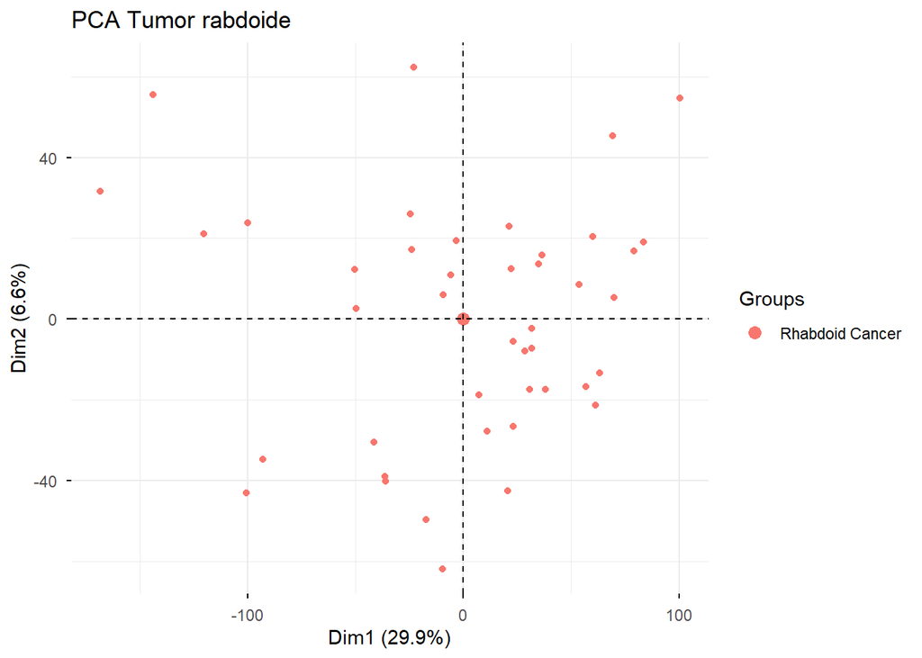

```r
# PCA rt
PCA_rt <- prcomp(t(assay(rt_rna_seq_fil, "TPM")), scale = T)
fviz_pca_ind(PCA_rt, habillage = rt_rna_seq_fil$CANCER_TYPE, label = "none", title = "PCA Tumor rabdoide") # Grafico según tipo tumor
```

### Variables clínicas

```r
# Resumen de las variables clínicas en html
view( dfSummary(as.data.frame(colData(rt_rna_seq_fil))))
```

```
## Error in `obj_components[[1]]`:
## ! subíndice fuera de  los límites
```

Después de una visualización global se escogen las variables con más interés para el estudio y se representan gráficamente.

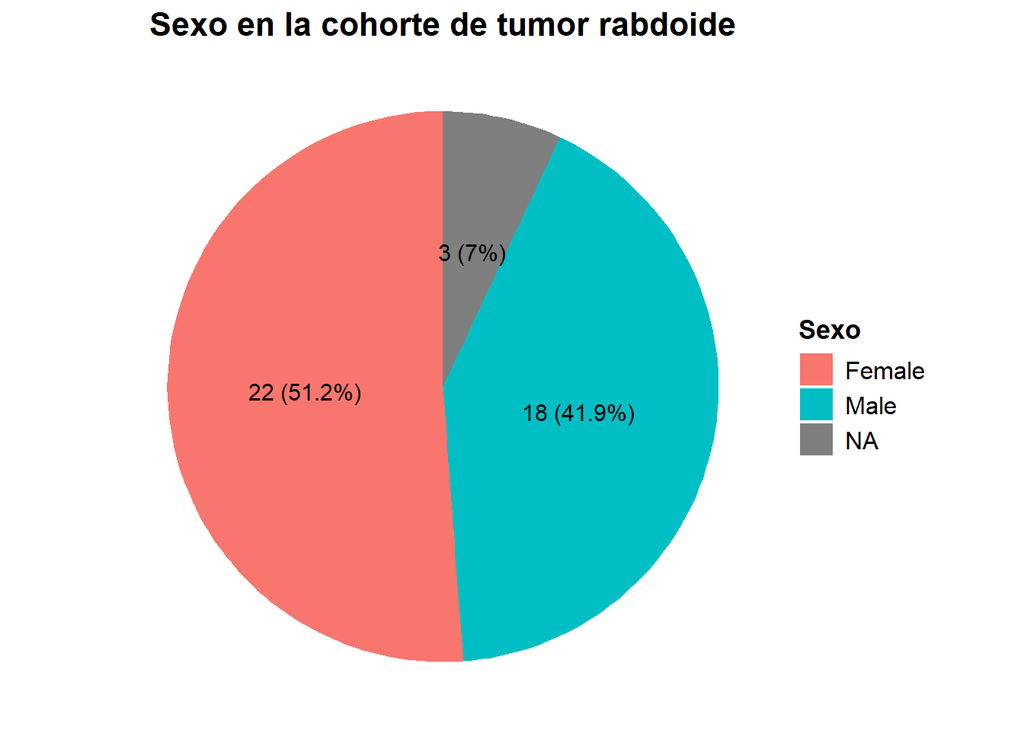

```r
# Análisis variables seleccionadas
plot_sex(as.data.frame(colData(rt_rna_seq_fil)),"tumor rabdoide", "sexo_rt.png")
```

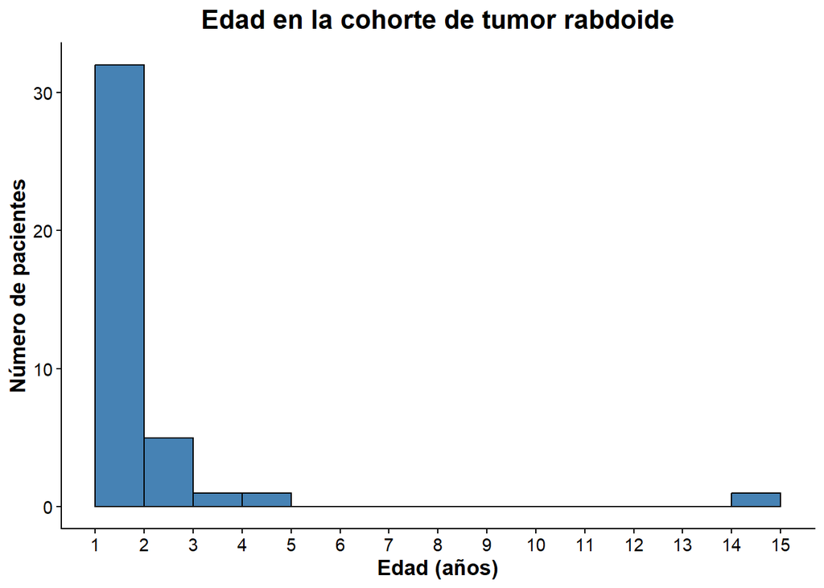

```r
plot_age(as.data.frame(colData(rt_rna_seq_fil)),"tumor rabdoide", "edad_rt.png")
```

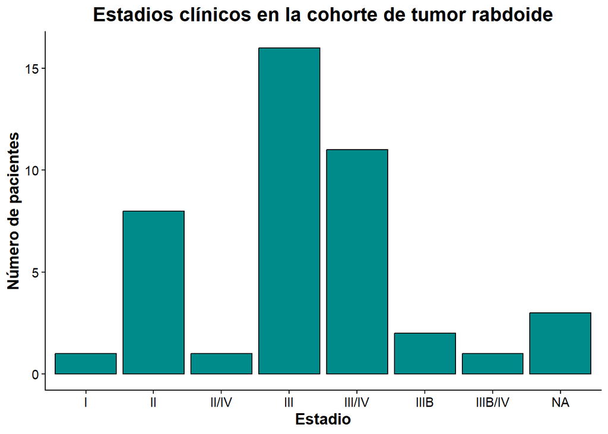

```r
plot_stage(as.data.frame(colData(rt_rna_seq_fil)),"tumor rabdoide", "estadio_rt.png")
```

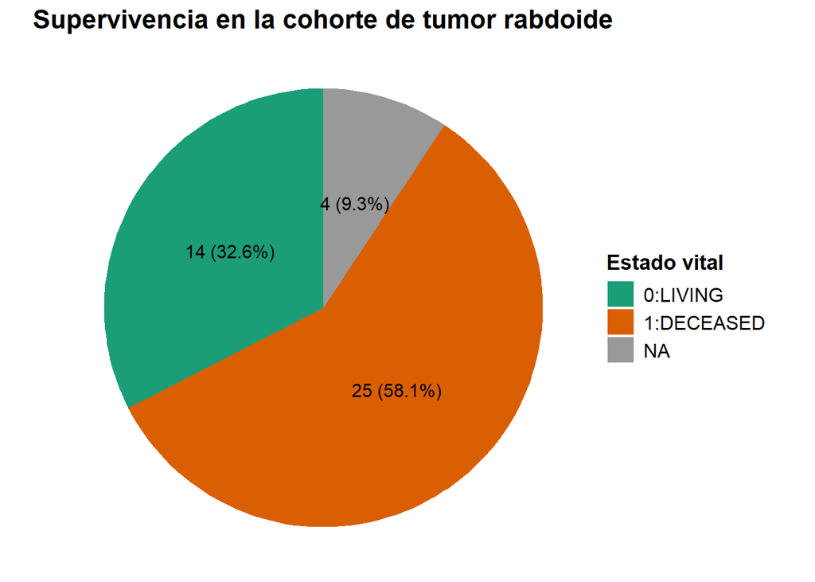

```r
plot_os(as.data.frame(colData(rt_rna_seq_fil)),"tumor rabdoide", "os_rt.png")
```

## *Pediatric Wilms’ Tumor (TARGET, 2018)*

### PCA

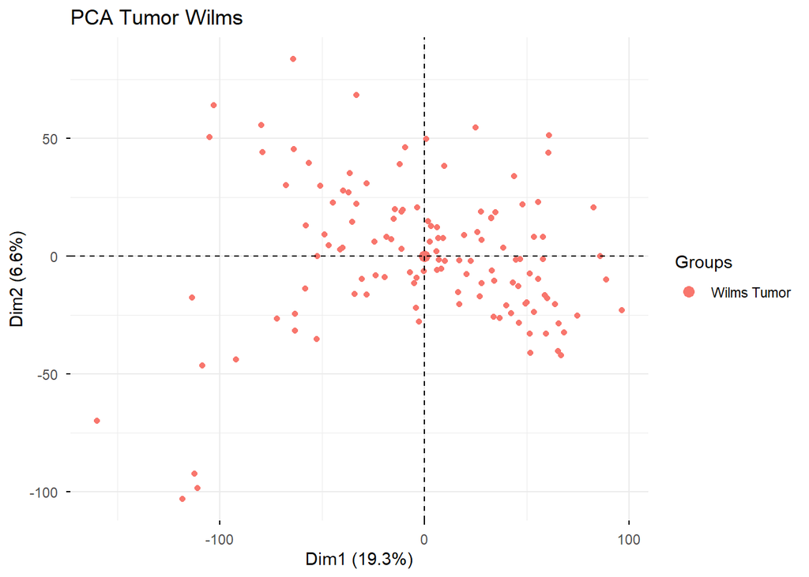

```r
PCA_wt <- prcomp(t(assay(wt_rna_seq_fil, "TPM")), scale = T)
fviz_pca_ind(PCA_wt, habillage = wt_rna_seq_fil$CANCER_TYPE, label = "none",
             title = "PCA Tumor Wilms")
```

```r
# Resumen de las variables clínicas
view(dfSummary(as.data.frame(colData(wt_rna_seq_fil))))
```

```
## Error in `obj_components[[1]]`:
## ! subíndice fuera de  los límites
```

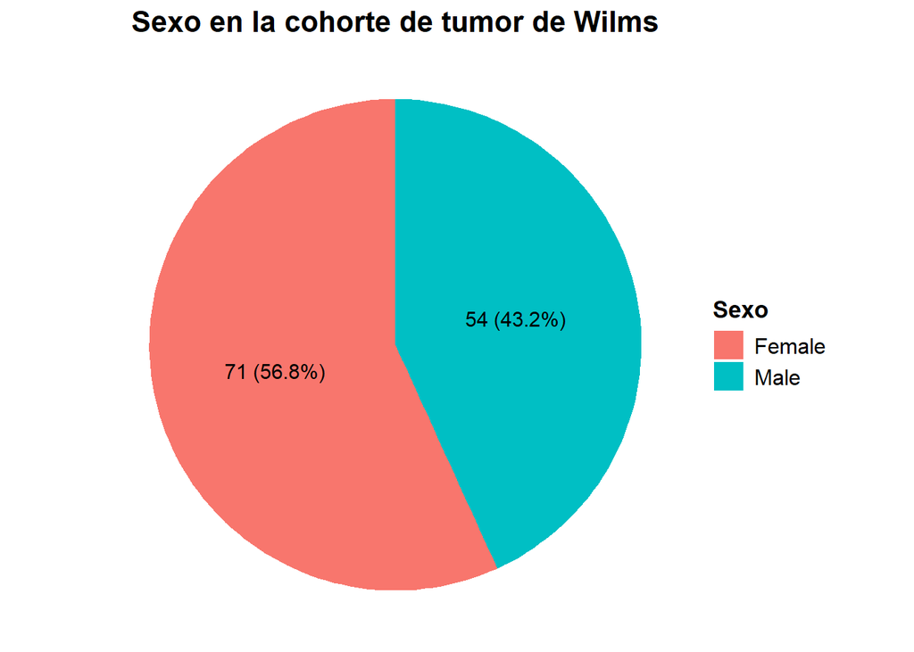

```r
# Análisis variables seleccionadas
plot_sex(as.data.frame(colData(wt_rna_seq_fil)),"tumor de Wilms", "sexo_wt.png")
```

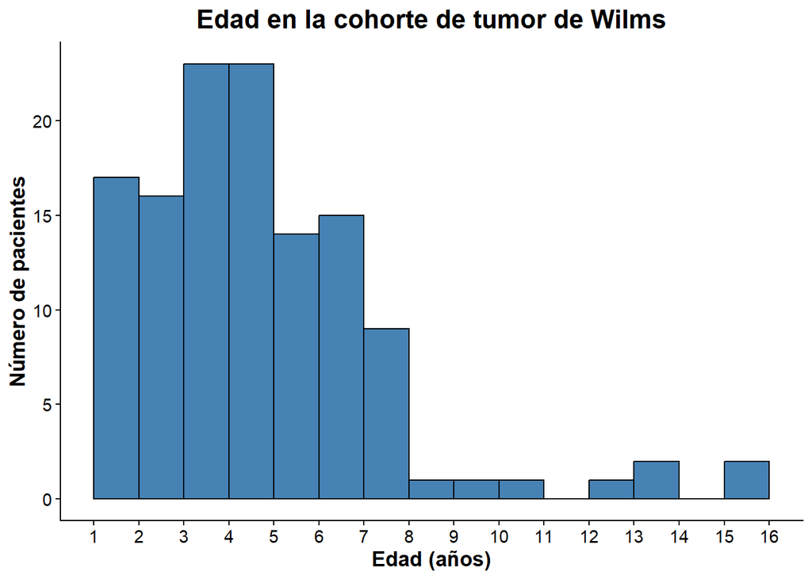

```r
plot_age(as.data.frame(colData(wt_rna_seq_fil)),"tumor de Wilms", "edad_wt.png")
```

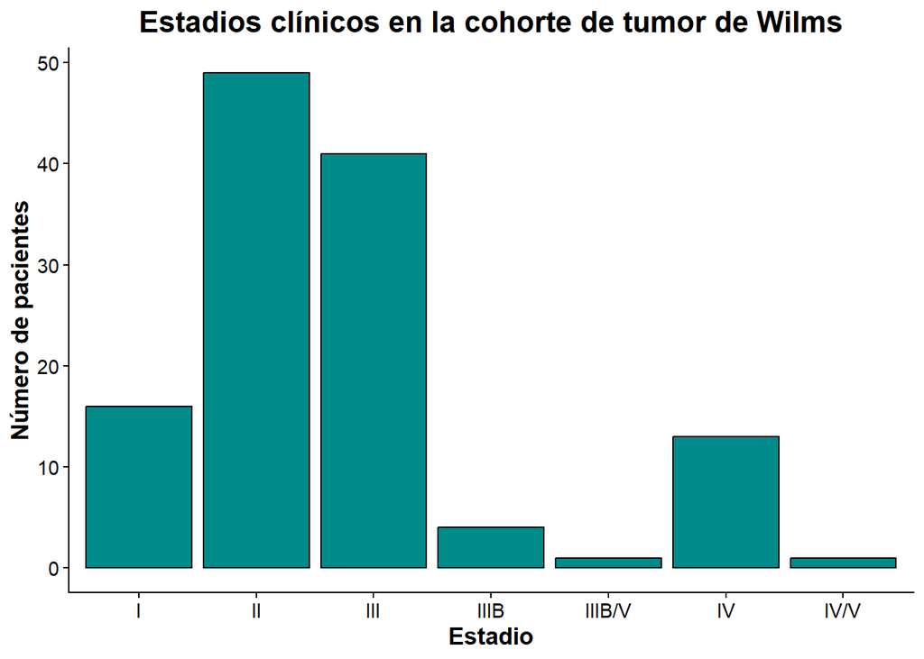

```r
plot_stage(as.data.frame(colData(wt_rna_seq_fil)),"tumor de Wilms", "estadio_wt.png")
```

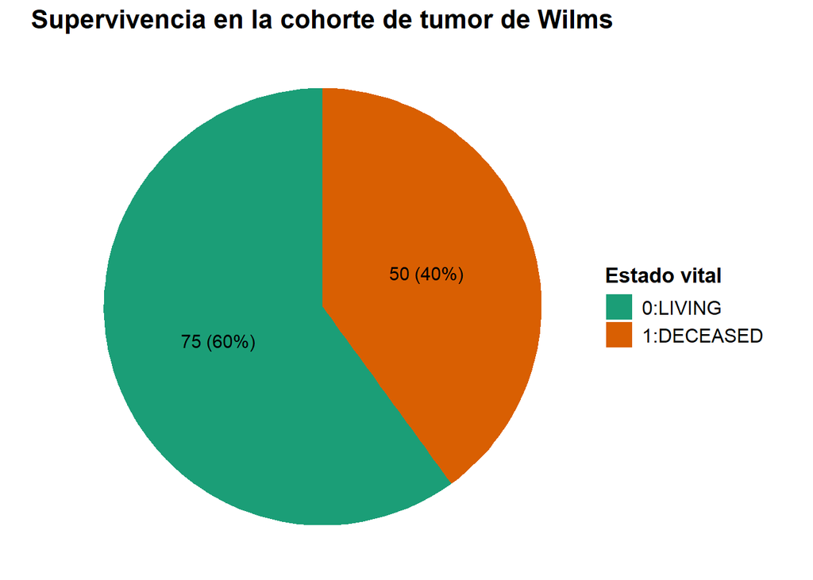

```r
plot_os(as.data.frame(colData(wt_rna_seq_fil)),"tumor de Wilms", "os_wt.png")
```

## *Pediatric Neuroblastoma (TARGET, 2018)*

### PCA

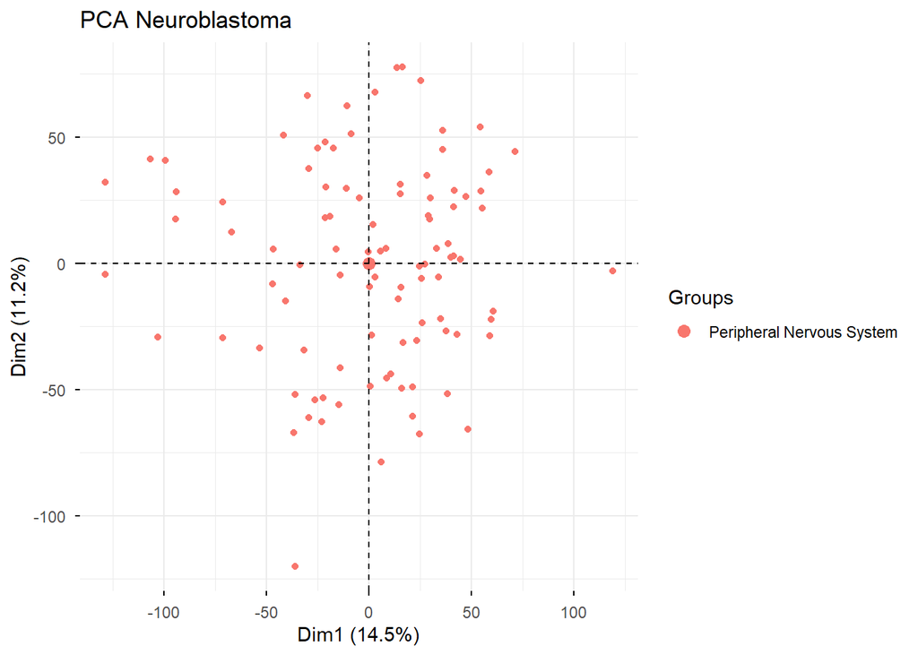

```r
PCA_nbl <- prcomp(t(assay(nbl_rna_seq_fil, "TPM")), scale = T)
fviz_pca_ind(PCA_nbl, habillage = nbl_rna_seq_fil$CANCER_TYPE,label = "none", title="PCA Neuroblastoma")
```

### Variables clínicas

```r
# Resumen de las variables clínicas
view(dfSummary(as.data.frame(colData(nbl_rna_seq_fil))))
```

```
## Error in `obj_components[[1]]`:
## ! subíndice fuera de  los límites
```

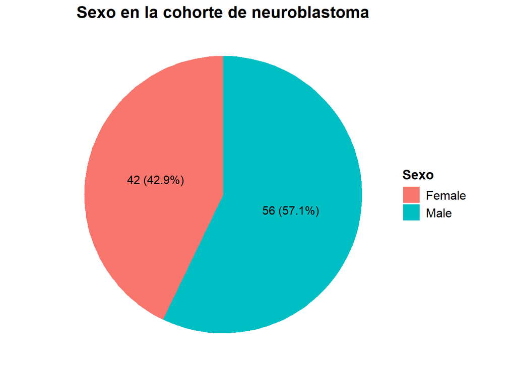

```r
# Análisis variables seleccionadas
plot_sex(as.data.frame(colData(nbl_rna_seq_fil)),"neuroblastoma", "sexo_nbl.png")
```

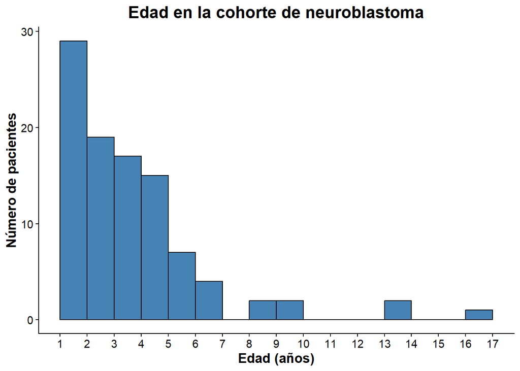

```r
plot_age(as.data.frame(colData(nbl_rna_seq_fil)),"neuroblastoma", "edad_nbl.png")
```

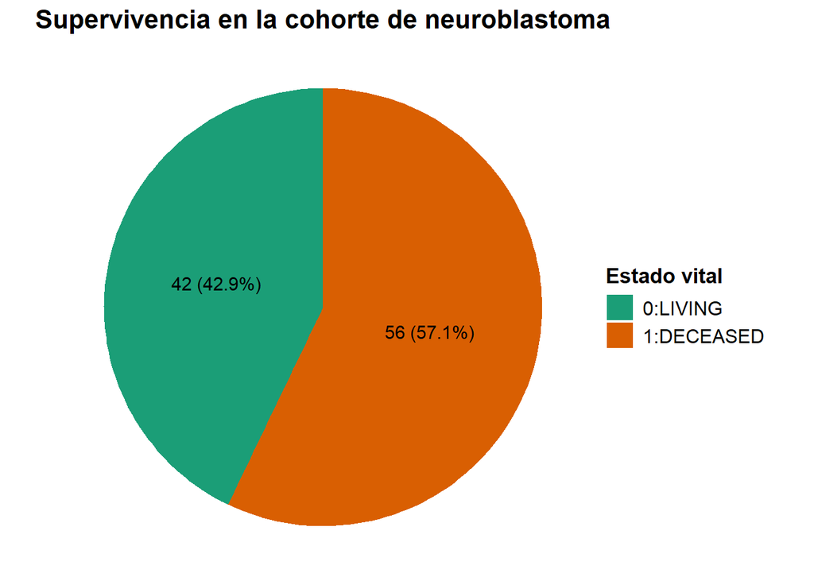

```r
plot_os(as.data.frame(colData(nbl_rna_seq_fil)),"neuroblastoma", "os_nbl.png")
```

En esta cohorte, el estadio clínico se encuentra definido como INSS_STAGE en los datos clínicos. Por ello, el gráfico se generó mediante un código específico y no utilizando la función general definida previamente.

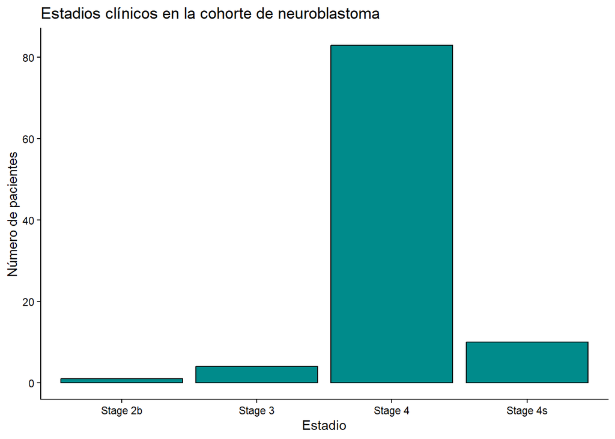

```r
# Estadios
ggplot(as.data.frame(colData(nbl_rna_seq_fil)), aes(x = INSS_STAGE)) +
  geom_bar(binwidth = 1,
           fill = "darkcyan",
           color = "black",
           boundary = 0) +
  theme_classic() +
  labs(title = "Estadios clínicos en la cohorte de neuroblastoma",
       x = "Estadio",
       y = "Número de pacientes")
```

```r
ggsave("estadio_nbl.png", width = 6, height = 6)
```

## *Pediatric Brain Cancer (CPTAC/CHOP, Cell 2020)*

### PCA

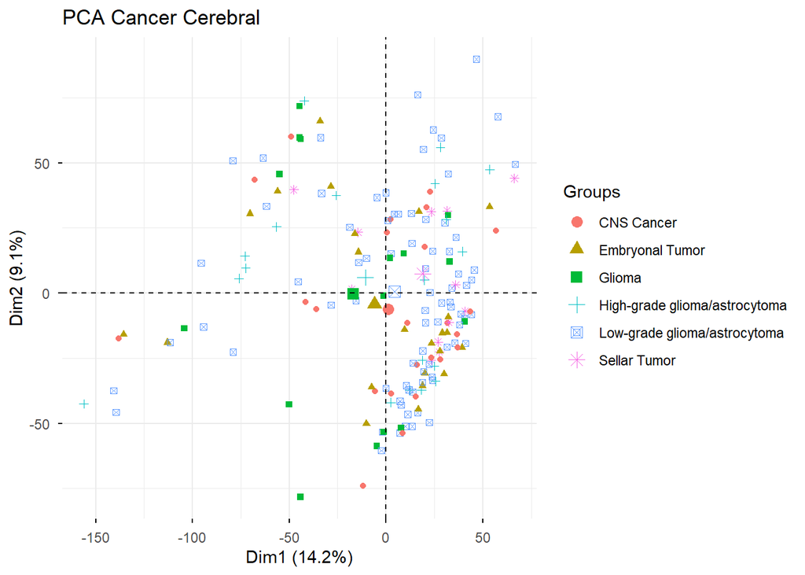

```r
# PCA rt
PCA_brain <- prcomp(t(assay(brain_rna_seq_fil, "TPM")), scale = T)
fviz_pca_ind(PCA_brain, habillage = brain_rna_seq_fil$CANCER_TYPE, label = "none", title= "PCA Cancer Cerebral")
```

Dentro de esta cohorte si hay diferentes tipos de cáncer cerebral.

### Variables clínicas

```r
# Resumen de las variables clínicas
view(dfSummary(as.data.frame(colData(brain_rna_seq_fil))))
```

[output not shown]

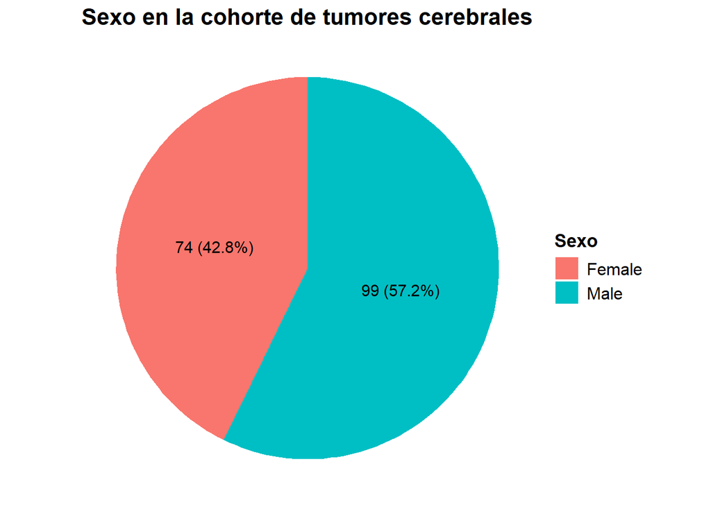

```r
# Análisis variables seleccionadas
plot_sex(as.data.frame(colData(brain_rna_seq_fil)),"tumores cerebrales", "sexo_brain.png")
```

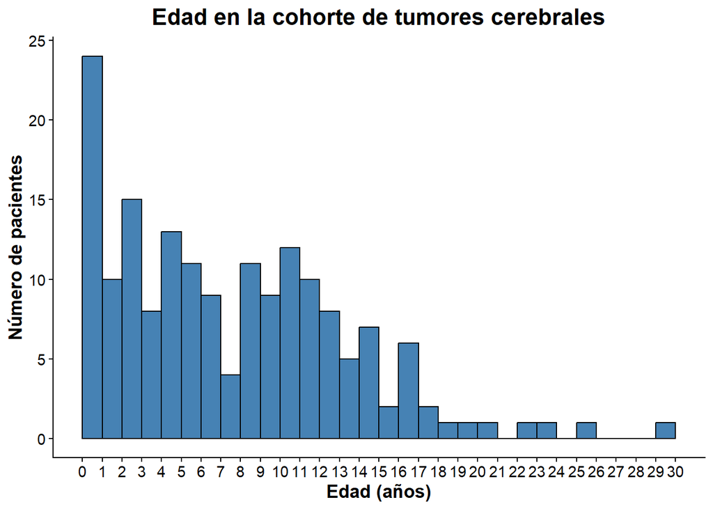

```r
plot_age(as.data.frame(colData(brain_rna_seq_fil)),"tumores cerebrales", "edad_brain.png")
```

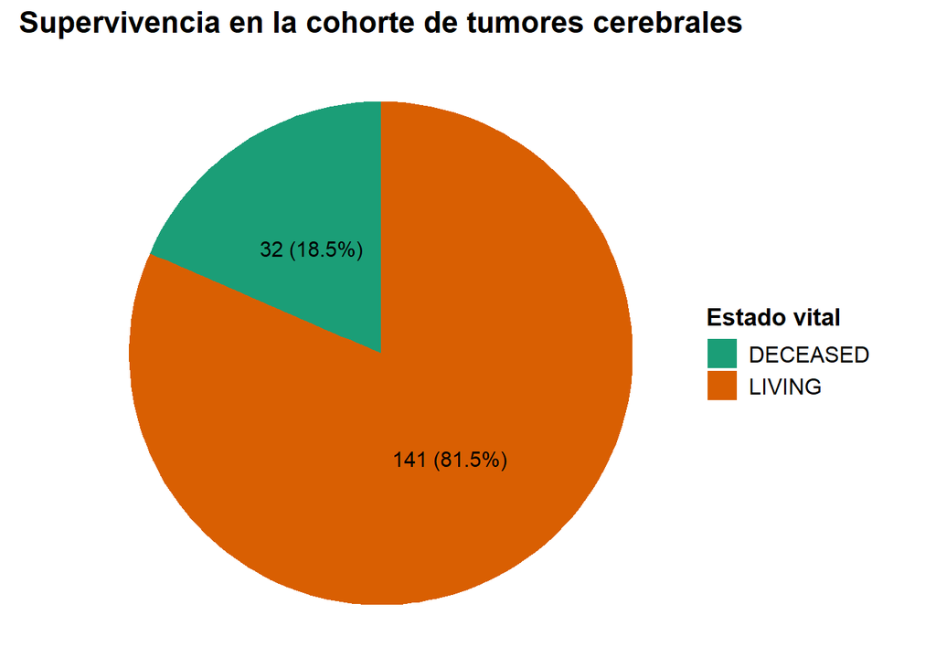

```r
plot_os(as.data.frame(colData(brain_rna_seq_fil)),"tumores cerebrales", "os_brain.png")
```

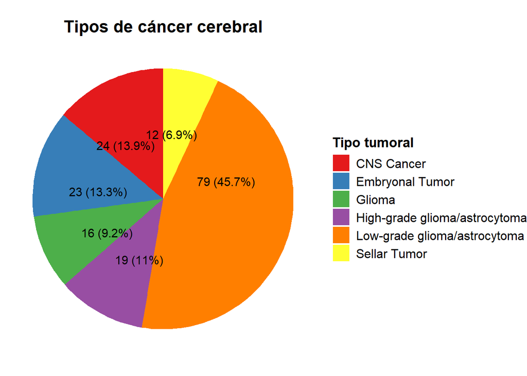

```r
# Tipos de cancer
ggplot(
  as.data.frame(colData(brain_rna_seq_fil)),
  aes(x = "", fill = CANCER_TYPE)
) +
  geom_bar(width = 1) +
  coord_polar("y") +
  theme_void() +
  scale_fill_brewer(palette = "Set1") +
  labs(
    title = "Tipos de cáncer cerebral",
    fill = "Tipo tumoral"
  ) +
  geom_text(
    stat = "count",
    size = 4,
    aes(label = paste0(
      after_stat(count),
      " (",
      round(after_stat(count / sum(count) * 100), 1),
      "%)"
    )),
    position = position_stack(vjust = 0.3)
  ) +
  theme(
    plot.title = element_text(
      size = 16,
      face = "bold",
      hjust = 0.5
    ),
    legend.title = element_text(
      size = 13,
      face = "bold"
    ),
    legend.text = element_text(
      size = 12
    )
  )
```

# Deconvolución

Para aplicar el método consensusTME, se utilizaron matrices de expresión previamente transformadas a formato TPM. Se verificó que los genes estuvieran anotados con identificadores HGNC y se eliminaron duplicados mediante la función avereps() del paquete limma.

El análisis se realizó utilizando la función consensusTMEAnalysis con statMethod = “ssgsea” y cancerType = “Unfiltered”, evitando el uso de referencias específicas de cáncer adulto en un contexto pediátrico.

El análisis se llevó a cabo de forma independiente en cada cohorte y posteriormente de manera conjunta. Dado que el método ssGSEA calcula scores de enriquecimiento de forma individual para cada muestra (single-sample), los resultados obtenidos pueden compararse entre cohortes.

Los scores ssGSEA, que reflejan el enriquecimiento relativo de firmas celulares, se representaron mediante heatmaps con escalado por fila (scale = “row”) para comparar patrones relativos entre muestras tumorales.

## Comparación intracohortes

```r
# Pediatric Rhabdoid Tumor
# Comprobar filas duplicadas.
sum(duplicated(rownames(rt_rna_seq_fil, "TPM")))
```

```
## [1] 197
```

```r
# Trabajo con assay "TPM"
m_rt <-avereps(assay(rt_rna_seq_fil, "TPM"))
sum(duplicated(rownames(m_rt)))
```

```
## [1] 0
```

```r
# ejecutar análisis
results_rt <- consensusTMEAnalysis(m_rt,cancerType = "Unfiltered",statMethod = "ssgsea")
```

```
## Producing ConsensusTME Estimates Using The Following Parameters:
##  Statistical Framework: "ssgsea"
##  Gene Sets For Cancer Type: "Unfiltered"
##  Sample Size: 43
```

```
## ℹ GSVA version 2.6.2
```

```
## ℹ Searching for rows with constant values
```

```
## ℹ Calculating ssGSEA scores for 19 gene sets
```

```
## ℹ Normalizing ssGSEA scores
```

```
## ✔ Calculations finished
```

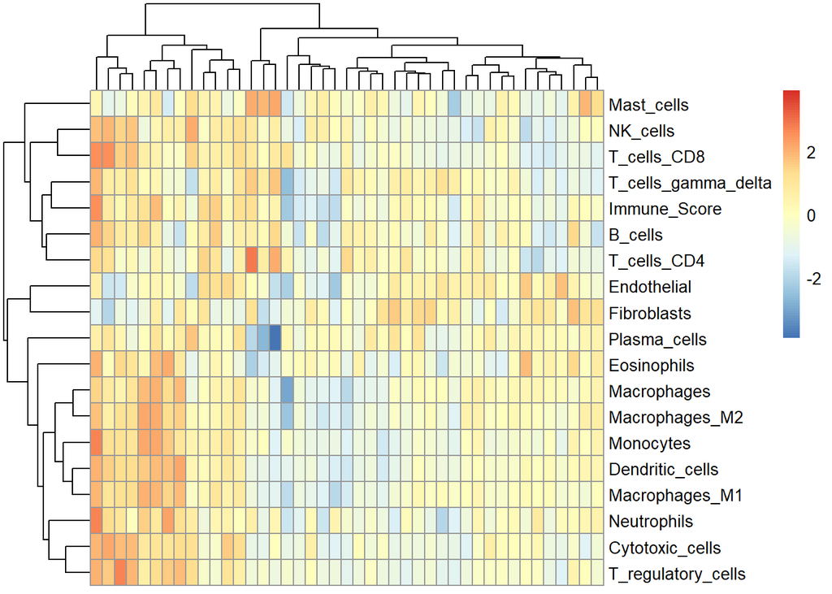

```r
# Representación con heatmap
pheatmap(results_rt,scale = "row",show_colnames = FALSE)
```

```r
# Pediatric Wilms Tumor
# Comprobar filas duplicadas.
sum(duplicated(rownames(wt_rna_seq_fil, "TPM")))
```

```
## [1] 34
```

```r
# Trabajo con assay "TPM"
m_wt <-avereps(assay(wt_rna_seq_fil, "TPM"))
sum(duplicated(rownames(m_wt)))
```

```
## [1] 0
```

```r
# ejecutar análisis
results_wt <- consensusTMEAnalysis(m_wt,cancerType = "Unfiltered",statMethod = "ssgsea")
```

```
## Producing ConsensusTME Estimates Using The Following Parameters:
##  Statistical Framework: "ssgsea"
##  Gene Sets For Cancer Type: "Unfiltered"
##  Sample Size: 125
```

```
## ℹ GSVA version 2.6.2
```

```
## ℹ Searching for rows with constant values
```

```
## ℹ Calculating ssGSEA scores for 19 gene sets
```

[output not shown]

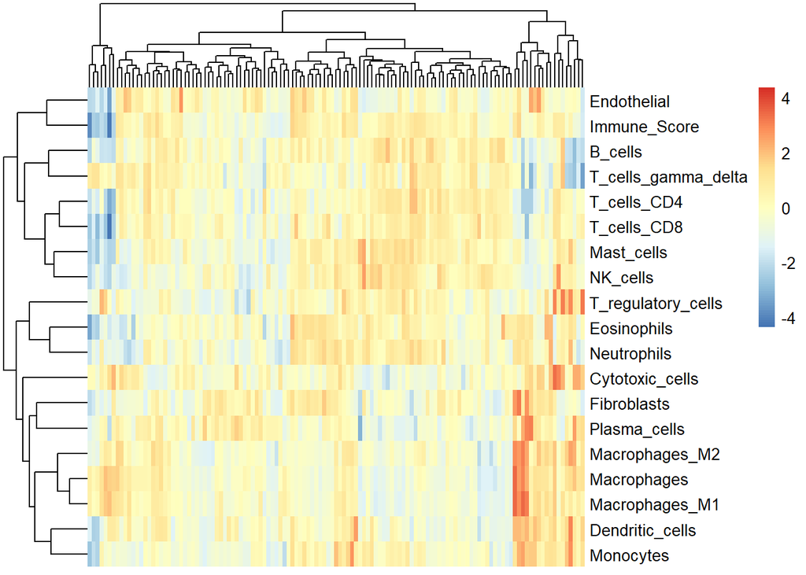

```r
# Representación con heatmap
pheatmap(results_wt,scale = "row",show_colnames = FALSE)
```

```r
# Pediatric Neuroblastoma
# Comprobar filas duplicadas.
sum(duplicated(rownames(nbl_rna_seq_fil, "TPM")))
```

```
## [1] 13
```

```r
# Trabajo con assay "TPM"
m_nbl <-avereps(assay(nbl_rna_seq_fil, "TPM"))
sum(duplicated(rownames(m_nbl)))
```

```
## [1] 0
```

```r
# ejecutar análisis
results_nbl <- consensusTMEAnalysis(m_nbl,cancerType = "Unfiltered",statMethod = "ssgsea")
```

```
## Producing ConsensusTME Estimates Using The Following Parameters:
##  Statistical Framework: "ssgsea"
##  Gene Sets For Cancer Type: "Unfiltered"
##  Sample Size: 98
```

```
## ℹ GSVA version 2.6.2
```

```
## ℹ Searching for rows with constant values
```

```
## ℹ Calculating ssGSEA scores for 19 gene sets
```

```
## ℹ Normalizing ssGSEA scores
```

```
## ✔ Calculations finished
```

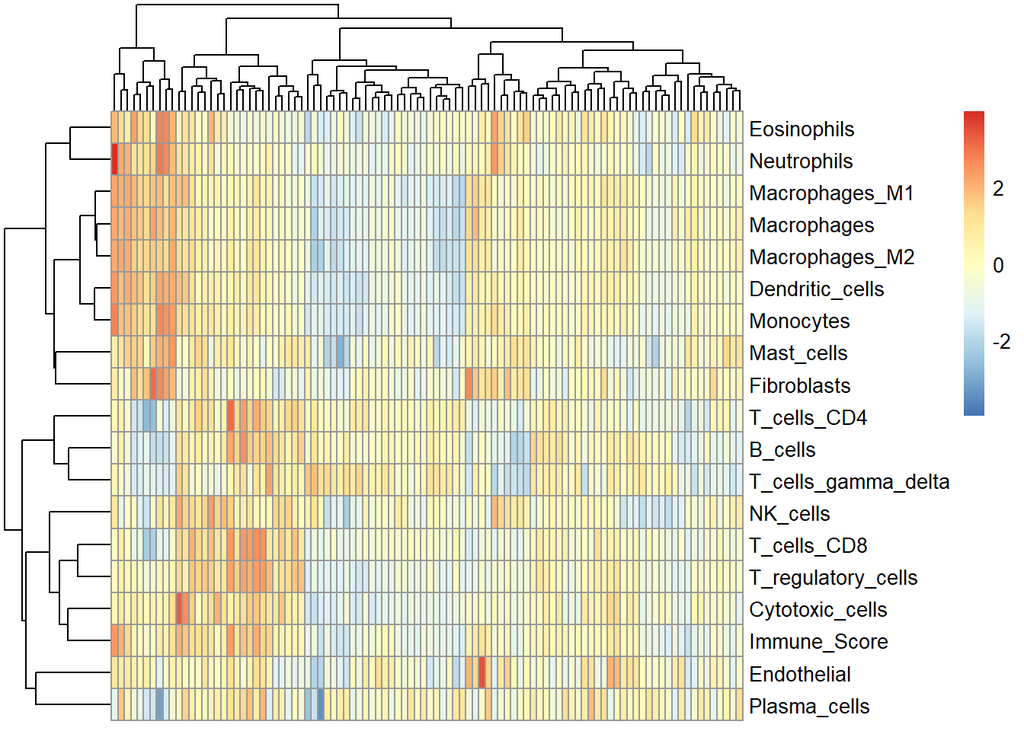

```r
# Representación con heatmap
pheatmap(results_nbl,scale = "row",show_colnames = FALSE)
```

```r
# Pediatric Brain Cancer
# Comprobar filas duplicadas.
sum(duplicated(rownames(brain_rna_seq_fil, "TPM")))
```

```
## [1] 2
```

```r
# Trabajo con assay "TPM"
m_brain <-avereps(assay(brain_rna_seq_fil, "TPM"))
sum(duplicated(rownames(m_brain)))
```

```
## [1] 0
```

```r
# ejecutar análisis
results_brain <- consensusTMEAnalysis(m_brain,cancerType = "Unfiltered",statMethod = "ssgsea")
```

```
## Producing ConsensusTME Estimates Using The Following Parameters:
##  Statistical Framework: "ssgsea"
##  Gene Sets For Cancer Type: "Unfiltered"
##  Sample Size: 173
```

```
## ℹ GSVA version 2.6.2
```

```
## ℹ Searching for rows with constant values
```

```
## ℹ Calculating ssGSEA scores for 19 gene sets
```

[output not shown]

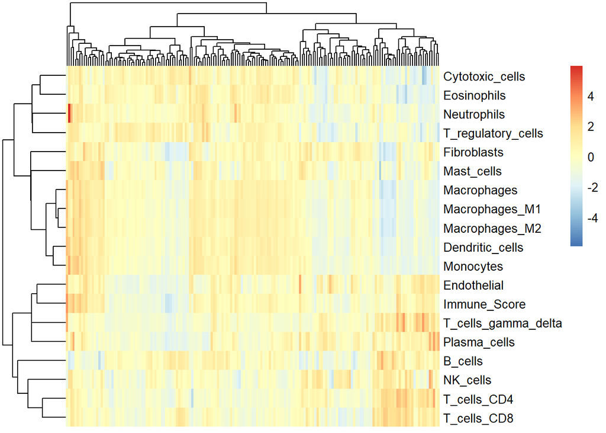

```r
# Representación con heatmap
pheatmap(results_brain,scale = "row",show_colnames = FALSE)
```

## Comparación entre cohortes

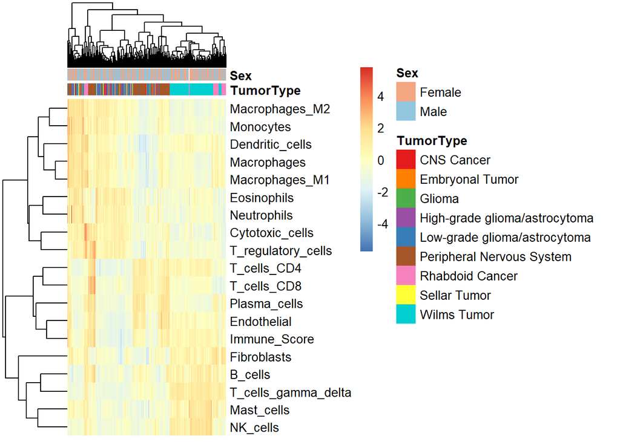

```r
# Integrar scores
results <- cbind(results_brain, results_nbl, results_rt, results_wt)
# Representación
colnames(results) <- make.unique(colnames(results))
annotation_res <- data.frame(
  TumorType = c(
    as.character(colData(brain_rna_seq_fil)$CANCER_TYPE),
    as.character(colData(nbl_rna_seq_fil)$CANCER_TYPE),
    as.character(colData(rt_rna_seq_fil)$CANCER_TYPE),
    as.character(colData(wt_rna_seq_fil)$CANCER_TYPE)
  ),
  Sex = c(
    as.character(colData(brain_rna_seq_fil)$SEX),
    as.character(colData(nbl_rna_seq_fil)$SEX),
    as.character(colData(rt_rna_seq_fil)$SEX),
    as.character(colData(wt_rna_seq_fil)$SEX)
  ),
  row.names = colnames(results)
)

ann_colors <- list(
  TumorType = c(
    "CNS Cancer"                    = "#E41A1C",
    "Embryonal Tumor"               = "#FF7F00",
    "Glioma"                        = "#4DAF4A",
    "High-grade glioma/astrocytoma" = "#984EA3",
    "Low-grade glioma/astrocytoma"  = "#377EB8",
    "Peripheral Nervous System"     = "#A65628",
    "Rhabdoid Cancer"               = "#F781BF",
    "Sellar Tumor"                  = "#FFFF33",
    "Wilms Tumor"                   = "#00CED1"
  ),
  Sex = c("Female" = "#F4A582", "Male" = "#92C5DE")
)

png("heatmap.png", width = 2400, height = 1600, res = 200)
pheatmap(
  results,
  scale             = "row",
  show_colnames     = FALSE,
  annotation_col    = annotation_res,
  annotation_colors = ann_colors
)
```

```r
dev.off()
```

# Análisis Clínico

## Sexo y edad

Para estudiar la asociación entre los perfiles de infiltración inmunitaria y el sexo y la edad se emplea el paquete limma.

El análisis se realizó mediante un modelo lineal múltiple utilizando como variable dependiente los scores de infiltración inmunitaria obtenidos por el método consensusTME y como variables independientes el sexo y la edad:

score∼SEX+AGE

- *Pediatric Rhabdoid Tumor (TARGET, 2018)*

En la exploración inicial de las variables, se observan pacientes que no tienen el sexo y/o edad anotada, en concreto 3, para evitar errores se eliminan estas muestras del análisis.

```r
# Comprobar valores NA
sum(is.na(rt_rna_seq_fil$SEX))
```

```
## [1] 3
```

```r
sum(is.na(rt_rna_seq_fil$AGE))
```

```
## [1] 3
```

```r
# Extraer los valores de sexo y edad
sex_edad_rt<-data.frame(rt_rna_seq_fil$SEX, rt_rna_seq_fil$AGE)
# Nombrar las columnas
colnames(sex_edad_rt)<- c("SEX","AGE")
# Nombrar las filas con los pacientes
rownames(sex_edad_rt)<- rt_rna_seq_fil$PATIENT_ID
# Guarda los valores diferentes a NA
sex_edad_rt<- sex_edad_rt[!is.na(sex_edad_rt$SEX),]
# Comprobar que se han eliminado
sum(is.na(sex_edad_rt))
```

```
## [1] 0
```

```r
dim(sex_edad_rt)
```

```
## [1] 40  2
```

```r
head(sex_edad_rt)
```

```
##                     SEX AGE
## TARGET-52-PABKLN   Male   2
## TARGET-52-PADYZI   Male   3
## TARGET-52-PAJLWM   Male   1
## TARGET-52-PAJMRB Female   2
## TARGET-52-PAJNER Female   1
## TARGET-52-PAJNFP   Male   1
```

```r
# Filtrar resultados
results_rt_fil <- results_rt[,rownames(sex_edad_rt)]
```

Se realiza el análisis

```r
# Análisis lineal
design <- model.matrix(~ sex_edad_rt$SEX + sex_edad_rt$AGE)
fit <- lmFit(results_rt_fil, design)
fit_rt <- eBayes(fit)
# Resultados
res_sex_rt <- topTable(
    fit_rt,
    coef = "sex_edad_rt$SEXMale",
    number = Inf,
    adjust.method = "BH"
)
res_age_rt <- topTable(
    fit_rt,
    coef = "sex_edad_rt$AGE",
    number = Inf,
    adjust.method = "BH"
)

res_sex_rt
```

```
##                             logFC     AveExpr           t   P.Value adj.P.Val
## Cytotoxic_cells     -0.0912022193 -0.26649915 -1.03818496 0.3056676 0.9669768
## Plasma_cells         0.0032356914  0.23076509  0.79279524 0.4327609 0.9669768
## Macrophages_M2      -0.0110147934  0.20288434 -0.78040767 0.4399281 0.9669768
## Mast_cells           0.0053738592  0.15789784  0.72624377 0.4720865 0.9669768
## Macrophages         -0.0067834480  0.29002808 -0.69745017 0.4897163 0.9669768
## Macrophages_M1      -0.0102613084  0.23216318 -0.69209425 0.4930358 0.9669768
## B_cells             -0.0037817268  0.08071846 -0.62071391 0.5384493 0.9669768
## Neutrophils         -0.0074663520 -0.05403888 -0.60805022 0.5467285 0.9669768
## T_cells_gamma_delta -0.0047180162  0.27237658 -0.44664504 0.6576364 0.9669768
## Immune_Score        -0.0014722822  0.25054674 -0.39502789 0.6950048 0.9669768
## Dendritic_cells     -0.0053747073  0.09156461 -0.35584217 0.7239033 0.9669768
## Monocytes           -0.0034371552  0.13265838 -0.30199010 0.7642867 0.9669768
## NK_cells             0.0031640468  0.14617787  0.30171805 0.7644926 0.9669768
## Endothelial         -0.0006660538  0.34128214 -0.14679499 0.8840607 0.9669768
## T_regulatory_cells  -0.0057710934 -0.20504782 -0.14482230 0.8856075 0.9669768
## T_cells_CD4          0.0003333580  0.27704972  0.08189461 0.9351553 0.9669768
## Eosinophils         -0.0008942937 -0.12459547 -0.05324217 0.9578146 0.9669768
## Fibroblasts          0.0002154047  0.34173464  0.04458749 0.9646668 0.9669768
## T_cells_CD8         -0.0002598377  0.13757326 -0.04167074 0.9669768 0.9669768
##                             B
## Cytotoxic_cells     -6.752425
## Plasma_cells        -6.976878
## Macrophages_M2      -6.986672
## Mast_cells          -7.027737
## Macrophages         -7.048398
## Macrophages_M1      -7.052151
## B_cells             -7.099473
## Neutrophils         -7.107342
## T_cells_gamma_delta -7.193636
## Immune_Score        -7.215720
## Dendritic_cells     -7.230691
## Monocytes           -7.248731
## NK_cells            -7.248815
## Endothelial         -7.284247
## T_regulatory_cells  -7.284541
## T_cells_CD4         -7.291824
## Eosinophils         -7.293801
## Fibroblasts         -7.294234
## T_cells_CD8         -7.294362
```

```r
res_age_rt
```

```
##                             logFC     AveExpr           t    P.Value adj.P.Val
## Endothelial         -0.0025126992  0.34128214 -2.55646781 0.01464129 0.2088769
## Macrophages_M1      -0.0072954833  0.23216318 -2.27150903 0.02879388 0.2088769
## T_cells_gamma_delta -0.0050614846  0.27237658 -2.21196833 0.03298057 0.2088769
## Immune_Score        -0.0015568199  0.25054674 -1.92829277 0.06122520 0.2482626
## Fibroblasts         -0.0019854170  0.34173464 -1.89717579 0.06533225 0.2482626
## Cytotoxic_cells     -0.0328357138 -0.26649915 -1.72549493 0.09246647 0.2928105
## Macrophages         -0.0031401843  0.29002808 -1.49044419 0.14426430 0.3915745
## Dendritic_cells     -0.0045371732  0.09156461 -1.38671067 0.17351614 0.4121008
## Macrophages_M2      -0.0039202846  0.20288434 -1.28221447 0.20744290 0.4359176
## B_cells             -0.0016117614  0.08071846 -1.22123705 0.22943031 0.4359176
## T_cells_CD4         -0.0006699818  0.27704972 -0.75981068 0.45200052 0.7407231
## T_regulatory_cells  -0.0058333236 -0.20504782 -0.67575818 0.50323767 0.7407231
## T_cells_CD8         -0.0009051066  0.13757326 -0.67008012 0.50681057 0.7407231
## Monocytes           -0.0013800292  0.13265838 -0.55973150 0.57890833 0.7856613
## Plasma_cells        -0.0001725909  0.23076509 -0.19521347 0.84625355 0.9459897
## NK_cells            -0.0004219447  0.14617787 -0.18574275 0.85362272 0.9459897
## Neutrophils          0.0003315000 -0.05403888  0.12462707 0.90146795 0.9459897
## Mast_cells           0.0001267011  0.15789784  0.07904503 0.93740668 0.9459897
## Eosinophils         -0.0002481024 -0.12459547 -0.06818744 0.94598971 0.9459897
##                             B
## Endothelial         -5.726903
## Macrophages_M1      -6.339426
## T_cells_gamma_delta -6.460513
## Immune_Score        -7.002271
## Fibroblasts         -7.058020
## Cytotoxic_cells     -7.351883
## Macrophages         -7.715042
## Dendritic_cells     -7.860291
## Macrophages_M2      -7.996993
## B_cells             -8.072220
## T_cells_CD4         -8.528797
## T_regulatory_cells  -8.589863
## T_cells_CD8         -8.593737
## Monocytes           -8.662657
## Plasma_cells        -8.803159
## NK_cells            -8.805008
## Neutrophils         -8.814730
## Mast_cells          -8.819491
## Eosinophils         -8.820310
```

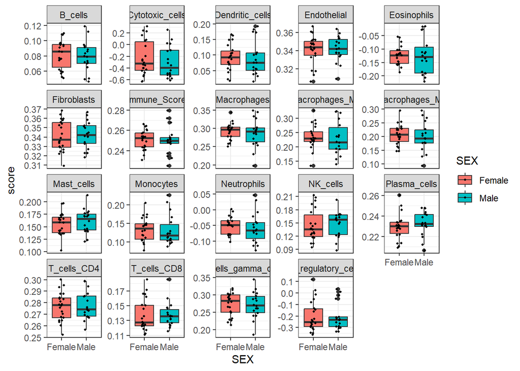

```r
plot_boxplot_sex(results_rt_fil,sex_edad_rt,"rt_sex_age")
```

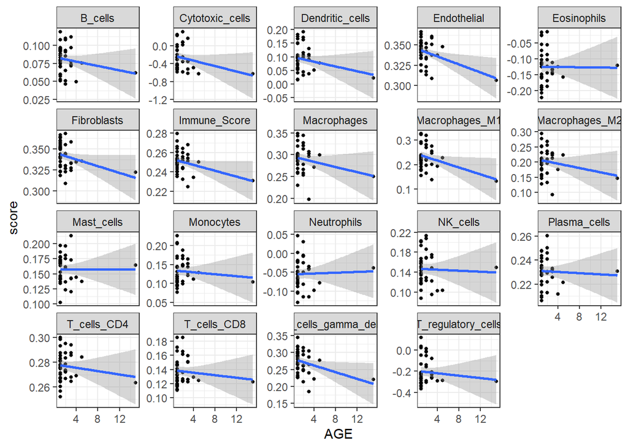

```r
plot_scatter_age(results_rt_fil,sex_edad_rt,"rt_sex_age")
```

- *Pediatric Brain Cancer (CPTAC/CHOP, Cell 2020)*

```r
analisis_limma(results_brain,brain_rna_seq_fil,"brain_sex_age")
```

```
## [[1]]
## [1] "brain_sex_age"
##
## $res_sex
##                             logFC     AveExpr            t   P.Value adj.P.Val
## Macrophages_M1       1.207197e-02  0.18933997  1.201830606 0.2310764 0.8841070
## Monocytes            8.535721e-03  0.18348274  1.178669748 0.2401529 0.8841070
## Macrophages_M2       1.080534e-02  0.23588672  1.127901644 0.2609277 0.8841070
## Eosinophils          1.045398e-02 -0.02432161  1.076804896 0.2830710 0.8841070
## Dendritic_cells      8.214106e-03  0.06946181  1.072191175 0.2851318 0.8841070
## NK_cells            -3.278917e-03  0.13771984 -1.032811672 0.3031378 0.8841070
## Immune_Score         1.827679e-03  0.21568137  0.838828541 0.4027264 0.8841070
## B_cells              2.595222e-03  0.02341141  0.836228888 0.4041829 0.8841070
## Macrophages          6.154168e-03  0.28063976  0.810468602 0.4187875 0.8841070
## Mast_cells          -2.510118e-03  0.10379704 -0.578998191 0.5633456 0.9649081
## Cytotoxic_cells      8.150519e-03 -0.23362332  0.549424333 0.5834248 0.9649081
## Neutrophils          3.074413e-03  0.02746784  0.446023941 0.6561393 0.9649081
## T_regulatory_cells  -3.280041e-03 -0.15600807 -0.407773626 0.6839455 0.9649081
## Fibroblasts          1.725018e-03  0.26597454  0.371145065 0.7109849 0.9649081
## T_cells_CD4         -8.152771e-04  0.26313146 -0.213542816 0.8311558 0.9825647
## T_cells_CD8          5.156822e-04  0.15501880  0.196925287 0.8441178 0.9825647
## Endothelial          5.075658e-04  0.28759258  0.145832676 0.8842237 0.9825647
## T_cells_gamma_delta -6.032537e-04  0.08617567 -0.086901243 0.9308508 0.9825647
## Plasma_cells        -1.200585e-05  0.16652528 -0.003721227 0.9970352 0.9970352
##                             B
## Macrophages_M1      -6.999910
## Monocytes           -7.027357
## Macrophages_M2      -7.085683
## Eosinophils         -7.141831
## Dendritic_cells     -7.146774
## NK_cells            -7.188115
## Immune_Score        -7.369417
## B_cells             -7.371594
## Macrophages         -7.392802
## Mast_cells          -7.553770
## Cytotoxic_cells     -7.570489
## Neutrophils         -7.622078
## T_regulatory_cells  -7.638453
## Fibroblasts         -7.652760
## T_cells_CD4         -7.698988
```

[output cut: 196 more lines]

```
## Eosinophils       -7.752225       -7.141831   -8.716832
## Macrophages      176.694268       -7.392802   -9.725663
## 14 more rows ...
##
## $F
##  [1]    78.020848   338.329308   112.887580     9.970698  1862.647530
##  [6]   781.574314  2565.848660    22.318816  6475.689497  4777.284230
## [11]   210.172658   513.930413   485.371867   827.325967  9308.673968
## [16]  4464.907658   875.897322  3632.846161 13358.276044
##
## $F.p.value
##  [1]  6.156290e-32  5.276697e-72  1.749592e-40  4.274292e-06 3.922415e-131
##  [6] 3.949122e-100 8.051820e-143  2.927101e-12 5.351109e-177 1.012730e-165
## [11]  2.286386e-57  9.538848e-86  7.921016e-84 4.059723e-102 1.719892e-190
## [16] 3.216292e-163 4.049533e-104 1.328300e-155 5.962797e-204
```

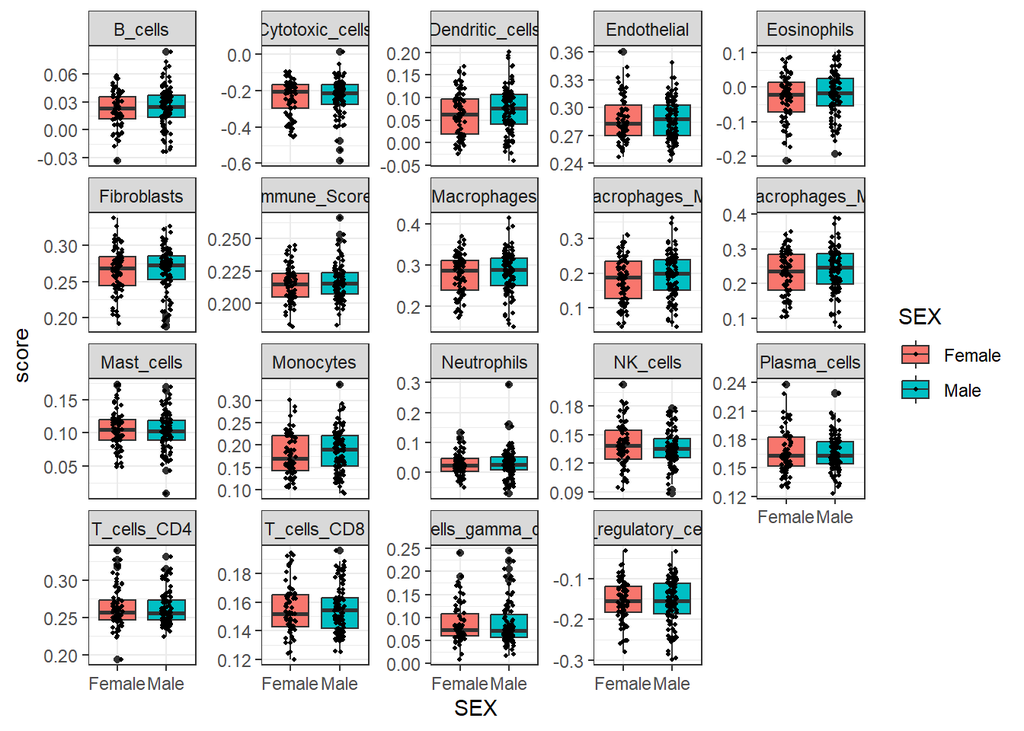

```r
plot_boxplot_sex(results_brain,brain_rna_seq_fil,"brain_sex_age")
```

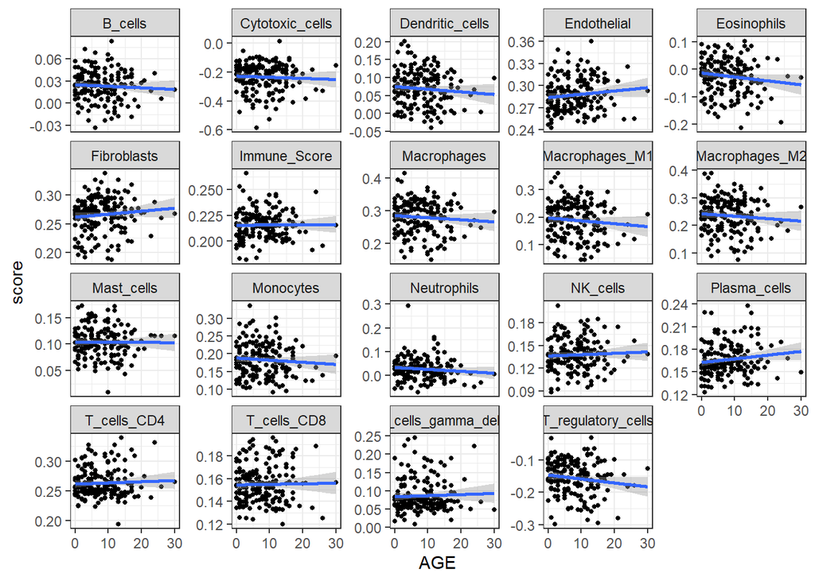

```r
plot_scatter_age(results_brain,brain_rna_seq_fil,"brain_sex_age")
```

- *Pediatric Wilms’ Tumor (TARGET, 2018)*

```r
analisis_limma(results_wt,wt_rna_seq_fil,"wt_sex_age")
```

```
## [[1]]
## [1] "wt_sex_age"
##
## $res_sex
##                             logFC     AveExpr          t   P.Value adj.P.Val
## T_cells_gamma_delta  0.0062253013  0.30431389  1.0428830 0.2990108 0.9148101
## Plasma_cells        -0.0028317644  0.16754145 -0.9834285 0.3272921 0.9148101
## Macrophages          0.0036713475  0.24208630  0.8759461 0.3827358 0.9148101
## Macrophages_M1       0.0046097880  0.15820549  0.8541631 0.3946450 0.9148101
## Macrophages_M2       0.0039413772  0.14115790  0.8079131 0.4206721 0.9148101
## Immune_Score         0.0013443580  0.24751896  0.7214254 0.4719921 0.9148101
## Fibroblasts         -0.0021748768  0.30375608 -0.6354770 0.5262765 0.9148101
## B_cells              0.0024512540  0.07512154  0.6257746 0.5326012 0.9148101
## T_regulatory_cells  -0.0033506691 -0.24489353 -0.6036820 0.5471466 0.9148101
## Monocytes           -0.0019084471  0.12536382 -0.5677250 0.5712378 0.9148101
## NK_cells            -0.0015117515  0.20085221 -0.4466136 0.6559251 0.9148101
## Eosinophils          0.0027188788 -0.09024207  0.4077222 0.6841736 0.9148101
## Dendritic_cells      0.0012628205  0.07431515  0.3658879 0.7150659 0.9148101
## T_cells_CD8          0.0008060853  0.15791424  0.3056010 0.7604156 0.9148101
## Mast_cells          -0.0012134095  0.16076093 -0.2273795 0.8204993 0.9148101
## T_cells_CD4          0.0006302595  0.30769673  0.2270033 0.8207912 0.9148101
## Cytotoxic_cells     -0.0027126558 -0.43271490 -0.1777686 0.8591919 0.9148101
## Endothelial          0.0004387549  0.32731890  0.1152274 0.9084493 0.9148101
## Neutrophils         -0.0005790597 -0.03699232 -0.1071896 0.9148101 0.9148101
##                             B
## T_cells_gamma_delta -7.374014
## Plasma_cells        -7.434159
## Macrophages         -7.534058
## Macrophages_M1      -7.552915
## Macrophages_M2      -7.591394
## Immune_Score        -7.657659
## Fibroblasts         -7.716145
## B_cells             -7.722284
## T_regulatory_cells  -7.735915
## Monocytes           -7.757058
## NK_cells            -7.818763
## Eosinophils         -7.835463
## Dendritic_cells     -7.851733
## T_cells_CD8         -7.872090
## Mast_cells          -7.893063
```

[output cut: 196 more lines]

```
## Eosinophils        29.02925       -7.835463   -7.502422
## Macrophages       179.96509       -7.534058   -8.779979
## 14 more rows ...
##
## $F
##  [1]   502.0839  1098.9741   632.4743   251.3370  4551.2570  1238.3271
##  [7]  4802.6579    65.1163 16752.7769  4889.1318  3545.3765  2655.9918
## [13]  1172.8007  1142.3319 10080.1521 10744.7969  1897.4049  4619.2856
## [19] 24065.9154
##
## $F.p.value
##  [1]  1.294334e-69  9.327751e-90  1.857833e-75  8.172748e-53 1.216468e-127
##  [6]  6.843796e-93 4.320487e-129  1.921363e-25 6.559217e-163 1.426467e-129
## [11] 6.438244e-121 3.623714e-113  1.837937e-91  9.021426e-91 3.899189e-149
## [16] 7.260149e-151 3.462202e-104 4.843574e-128 9.629825e-173
```

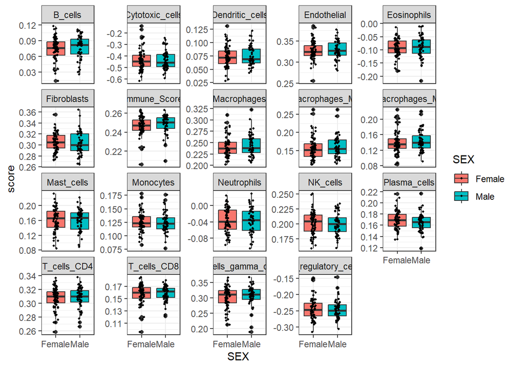

```r
plot_boxplot_sex(results_wt,wt_rna_seq_fil,"wt_sex_age")
```

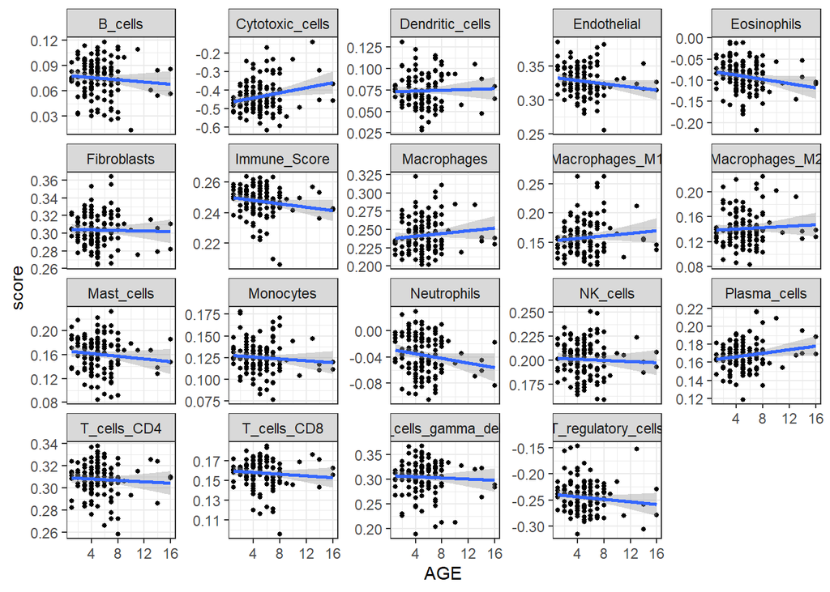

```r
plot_scatter_age(results_wt,wt_rna_seq_fil,"wt_sex_age")
```

- *Pediatric Neuroblastoma (TARGET, 2018)*

```r
analisis_limma(results_nbl,nbl_rna_seq_fil,"nbl_sex_age")
```

```
## [[1]]
## [1] "nbl_sex_age"
##
## $res_sex
##                             logFC     AveExpr          t   P.Value adj.P.Val
## Mast_cells          -0.0055625983  0.09890120 -1.0704233 0.2870843 0.8251704
## T_regulatory_cells  -0.0211834094 -0.20705766 -0.8130649 0.4181714 0.8251704
## T_cells_CD8         -0.0036914536  0.21177401 -0.7718080 0.4421038 0.8251704
## Endothelial         -0.0031723094  0.38957633 -0.7197146 0.4734308 0.8251704
## Immune_Score        -0.0023867768  0.26089670 -0.7169355 0.4751362 0.8251704
## B_cells             -0.0053799878  0.05899241 -0.6875980 0.4933464 0.8251704
## Macrophages_M2      -0.0076964809  0.20749825 -0.6222774 0.5352191 0.8251704
## NK_cells            -0.0028373467  0.13526556 -0.5877399 0.5580722 0.8251704
## Macrophages         -0.0051626498  0.26528293 -0.5803190 0.5630448 0.8251704
## T_cells_gamma_delta -0.0067198198  0.12912585 -0.5608786 0.5761732 0.8251704
## Macrophages_M1      -0.0066266586  0.18489950 -0.5198962 0.6043200 0.8251704
## Plasma_cells        -0.0016159101  0.25944330 -0.4138072 0.6799286 0.8251704
## Neutrophils         -0.0038876283 -0.03455891 -0.3813485 0.7037784 0.8251704
## Monocytes           -0.0040488119  0.16943030 -0.3702436 0.7120080 0.8251704
## Fibroblasts          0.0023045833  0.25865695  0.3645089 0.7162712 0.8251704
## Eosinophils          0.0046368293 -0.10742186  0.3602804 0.7194206 0.8251704
## Dendritic_cells     -0.0033545260  0.05119552 -0.2849748 0.7762708 0.8251704
## Cytotoxic_cells     -0.0088139801 -0.27008710 -0.2778216 0.7817404 0.8251704
## T_cells_CD4         -0.0008292058  0.33206443 -0.1879959 0.8512725 0.8512725
##                             B
## Mast_cells          -6.781860
## T_regulatory_cells  -7.023484
## T_cells_CD8         -7.056169
## Endothelial         -7.095038
## Immune_Score        -7.097036
## B_cells             -7.117662
## Macrophages_M2      -7.160520
## NK_cells            -7.181467
## Macrophages         -7.185813
## T_cells_gamma_delta -7.196937
## Macrophages_M1      -7.219155
## Plasma_cells        -7.268879
## Neutrophils         -7.281843
## Monocytes           -7.286037
## Fibroblasts         -7.288154
```

[output cut: 196 more lines]

```
## Eosinophils       19.691866       -7.289694   -8.233884
## Macrophages       99.348944       -7.185813   -9.090078
## 14 more rows ...
##
## $F
##  [1]    78.05983    99.31844    25.94800    96.02103  1218.15509   496.76670
##  [7]  1075.53413    15.81361  7763.77786  2685.91581   159.25175    86.73800
## [13]   288.37116   385.69629 10701.59819  2292.91103   328.89695  6047.00680
## [19]  8412.75902
##
## $F.p.value
##  [1]  9.061955e-26  1.822063e-29  2.076243e-12  6.211418e-29  7.680807e-77
##  [6]  9.993406e-59  2.729921e-74  1.899489e-08 2.141012e-115  3.379187e-93
## [11]  2.381271e-37  2.339886e-27  3.459537e-48  9.130051e-54 3.918061e-122
## [16]  6.586929e-90  1.082770e-50 3.724131e-110 4.425272e-117
```

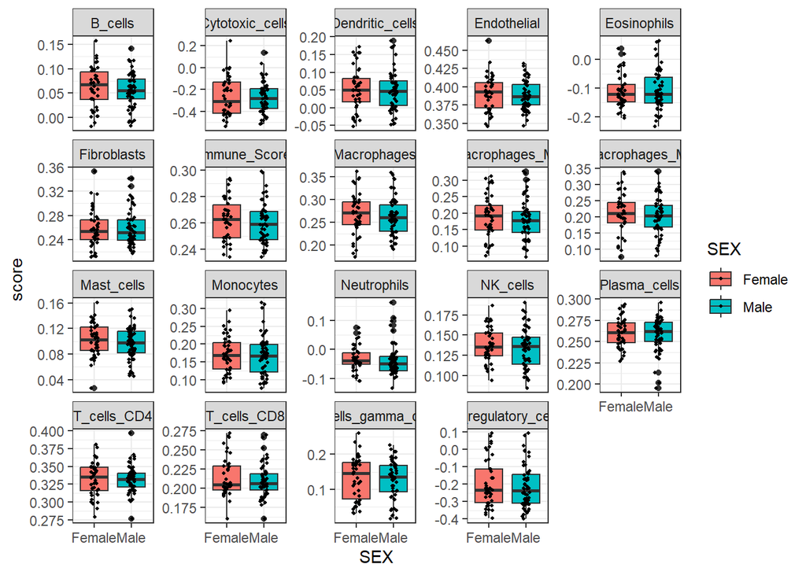

```r
plot_boxplot_sex(results_nbl,nbl_rna_seq_fil,"nbl_sex_age")
```

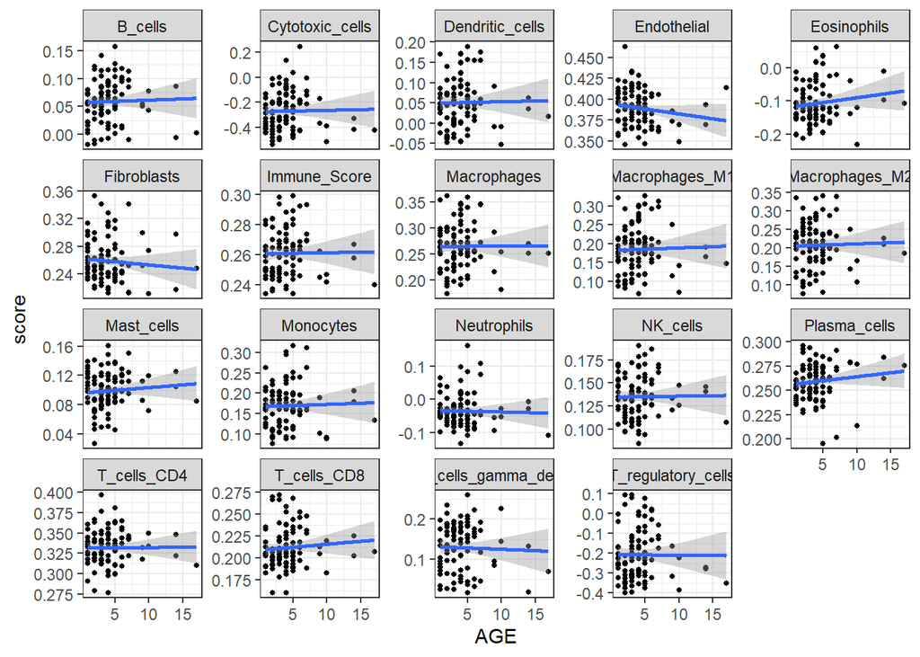

```r
plot_scatter_age(results_nbl,nbl_rna_seq_fil,"nbl_sex_age")
```

## Supervivencia

```r
# Preparar datos de cada cohorte
data_surv_nbl <- preparar_cohorte(nbl_rna_seq_fil,   results_nbl)
data_surv_rt <- preparar_cohorte(rt_rna_seq_fil,    results_rt)
data_surv_wt <- preparar_cohorte(wt_rna_seq_fil,    results_wt)

# Preparar datos para brain
data_surv_brain <-  data.frame( sample_id = brain_rna_seq_fil$PATIENT_ID, OS_STATUS = brain_rna_seq_fil$OS_STATUS, OS_MONTHS = brain_rna_seq_fil$OS_MONTHS ) %>% mutate(OS_STATUS = c("DECEASED" = 1, "LIVING"   = 0)[OS_STATUS])
results_brain_t <- as.data.frame(t(results_brain)) %>% rownames_to_column("sample_id")
data_surv_brain <- inner_join(data_surv_brain, results_brain_t, by = "sample_id")

# Nombres de los tipos celulares inmunes
tip_cel <- rownames(results)

#Agrupar en lista las cohortes caracterizadas
data_list <- list( NBL = categorizar(data_surv_nbl),RT = categorizar(data_surv_rt), WT = categorizar(data_surv_wt), BRAIN = categorizar(data_surv_brain))

# Crear lista de fórmulas
formulas <- lapply(tip_cel, function(cel) {
  as.formula(paste0("Surv(OS_MONTHS, OS_STATUS) ~ ", cel, "_group"))
})
names(formulas) <- tip_cel
```

### Tabla de p.valores

```r
# Por cohorte
pvals_NBL   <- c()
pvals_RT    <- c()
pvals_WT    <- c()
pvals_BRAIN <- c()

for (cel in names(formulas)) {
  fit <- survfit(formulas[[cel]], data = data_list$NBL)
  pvals_NBL[cel] <- round(surv_pvalue(fit, data = data_list$NBL)$pval, 4)

  fit <- survfit(formulas[[cel]], data = data_list$RT)
  pvals_RT[cel] <- round(surv_pvalue(fit, data = data_list$RT)$pval, 4)

  fit <- survfit(formulas[[cel]], data = data_list$WT)
  pvals_WT[cel] <- round(surv_pvalue(fit, data = data_list$WT)$pval, 4)

  fit <- survfit(formulas[[cel]], data = data_list$BRAIN)
  pvals_BRAIN[cel] <- round(surv_pvalue(fit, data = data_list$BRAIN)$pval, 4)
}

tabla_pval <- data.frame(
  NBL   = pvals_NBL,
  RT    = pvals_RT,
  WT    = pvals_WT,
  BRAIN = pvals_BRAIN
)

tabla_pval
```

```
##                        NBL     RT     WT  BRAIN
## B_cells             0.9186 0.4777 0.5432 0.5285
## Cytotoxic_cells     0.7712 0.4795 0.7296 0.1550
## Dendritic_cells     0.5538 0.2492 0.8981 0.6705
## Eosinophils         0.3202 0.3619 0.0838 0.4227
## Macrophages         0.5459 0.3244 0.9711 0.5998
## Mast_cells          0.0128 0.0061 0.2291 0.6593
## NK_cells            0.0116 0.6063 0.5199 0.2245
## Neutrophils         0.0671 0.9247 0.5036 0.2838
## T_cells_CD4         0.9325 0.3948 0.0060 0.9909
## T_cells_CD8         0.7083 0.3054 0.0040 0.0933
## T_cells_gamma_delta 0.0067 0.5006 0.0761 0.8574
## T_regulatory_cells  0.6172 0.3915 0.7230 0.9753
## Macrophages_M1      0.8395 0.4213 0.5867 0.3807
## Macrophages_M2      0.8590 0.5968 0.8551 0.5954
## Endothelial         0.1776 0.0814 0.3869 0.9962
## Fibroblasts         0.7947 0.2620 0.0477 0.4057
## Monocytes           0.3863 0.5610 0.7615 0.5273
## Plasma_cells        0.2292 0.9747 0.8104 0.6258
## Immune_Score        0.4866 0.9251 0.0078 0.4814
```

```r
write.csv(tabla_pval, "pval_surv.csv")
```

### Graficas de supervivencia

```r
# Generar todos los plots de todas las cohortes
plots_todos <- list()

for (cohort in names(data_list)) {
  for (cel in names(formulas)) {
    fit  <- survfit(formulas[[cel]], data = data_list[[cohort]])
    pval <- round(surv_pvalue(fit, data = data_list[[cohort]])$pval, 4)
    p <- ggsurvplot(
      fit,
      data        = data_list[[cohort]],
      size        = 1,
      palette     = c("#2196F3", "#F44336"),
      conf.int    = FALSE,
      pval        = pval,
      pval.coord  = c(90, 0.90),
      risk.table  = FALSE,
      legend.labs = c("Low", "High"),
      title       = paste0(cohort, " - ", cel),
      ggtheme     = theme_bw()
    )
    plots_todos[[paste0(cohort, "_", cel)]] <- p$plot
  }
}
# Guardar en PDF
pdf("KM_todas_cohortes.pdf", width = 16, height = 8)
print(gridExtra::marrangeGrob(grobs = plots_todos, nrow = 2, ncol = 4, top = NULL))
```

```r
dev.off()
```

# Impacto en sostenibilidad

```r
# Pon esto en el último chunk
tiempo_seg <- (proc.time() - inicio)["elapsed"]

watts_cpu  <- 15                          # ajusta si tienes un CPU más potente
kwh        <- (watts_cpu * tiempo_seg) / (1000 * 3600)
co2_gramos <- kwh * 450                   # ~450 gCO2/kWh para México

cat(sprintf("Tiempo de ejecución: %.2f s\n", tiempo_seg))
```

```
## Tiempo de ejecución: 370.11 s
```

```r
cat(sprintf("Energía consumida:   %.6f kWh\n", kwh))
```

```
## Energía consumida:   0.001542 kWh
```

```r
cat(sprintf("CO₂ estimado:        %.4f g CO₂\n", co2_gramos))
```

```
## CO₂ estimado:        0.6940 g CO₂
```